# ProblemSet2

Andrew Price

September 3, 2018

## 5.2.4 Exercises

### 1. Find all flights that:

Had an arrival delay of two or more hours Flew to Houston (IAH or HOU) Were operated by United, American, or Delta Departed in summer (July, August, and September) Arrived more than two hours late, but didnât leave late Were delayed by at least an hour, but made up over 30 minutes in flight Departed between midnight and 6am (inclusive)

```r
(two_hour_delay <- filter(flights,arr_delay >= 120))
```

```
## # A tibble: 10,200 x 19
##     year month   day dep_time sched_dep_time dep_delay arr_time
##    <int> <int> <int>    <int>          <int>     <dbl>    <int>
##  1  2013     1     1      811            630       101     1047
##  2  2013     1     1      848           1835       853     1001
##  3  2013     1     1      957            733       144     1056
##  4  2013     1     1     1114            900       134     1447
##  5  2013     1     1     1505           1310       115     1638
##  6  2013     1     1     1525           1340       105     1831
##  7  2013     1     1     1549           1445        64     1912
##  8  2013     1     1     1558           1359       119     1718
##  9  2013     1     1     1732           1630        62     2028
## 10  2013     1     1     1803           1620       103     2008
## # ... with 10,190 more rows, and 12 more variables: sched_arr_time <int>,
## #   arr_delay <dbl>, carrier <chr>, flight <int>, tailnum <chr>,
## #   origin <chr>, dest <chr>, air_time <dbl>, distance <dbl>, hour <dbl>,
## #   minute <dbl>, time_hour <dttm>
```

```r
(houston <- filter(flights, dest == "IAH" | dest == "HOU"))
```

```
## # A tibble: 9,313 x 19
##     year month   day dep_time sched_dep_time dep_delay arr_time
##    <int> <int> <int>    <int>          <int>     <dbl>    <int>
##  1  2013     1     1      517            515         2      830
##  2  2013     1     1      533            529         4      850
##  3  2013     1     1      623            627        -4      933
##  4  2013     1     1      728            732        -4     1041
##  5  2013     1     1      739            739         0     1104
##  6  2013     1     1      908            908         0     1228
##  7  2013     1     1     1028           1026         2     1350
##  8  2013     1     1     1044           1045        -1     1352
##  9  2013     1     1     1114            900       134     1447
## 10  2013     1     1     1205           1200         5     1503
## # ... with 9,303 more rows, and 12 more variables: sched_arr_time <int>,
## #   arr_delay <dbl>, carrier <chr>, flight <int>, tailnum <chr>,
## #   origin <chr>, dest <chr>, air_time <dbl>, distance <dbl>, hour <dbl>,
## #   minute <dbl>, time_hour <dttm>
```

```r
(operated <- filter(flights, carrier == "AA" | carrier == "UA" | carrier == "DL" ))
```

```
## # A tibble: 139,504 x 19
##     year month   day dep_time sched_dep_time dep_delay arr_time
##    <int> <int> <int>    <int>          <int>     <dbl>    <int>
##  1  2013     1     1      517            515         2      830
##  2  2013     1     1      533            529         4      850
##  3  2013     1     1      542            540         2      923
##  4  2013     1     1      554            600        -6      812
##  5  2013     1     1      554            558        -4      740
##  6  2013     1     1      558            600        -2      753
##  7  2013     1     1      558            600        -2      924
##  8  2013     1     1      558            600        -2      923
##  9  2013     1     1      559            600        -1      941
## 10  2013     1     1      559            600        -1      854
## # ... with 139,494 more rows, and 12 more variables: sched_arr_time <int>,
## #   arr_delay <dbl>, carrier <chr>, flight <int>, tailnum <chr>,
## #   origin <chr>, dest <chr>, air_time <dbl>, distance <dbl>, hour <dbl>,
## #   minute <dbl>, time_hour <dttm>
```

```r
(summer_depart <- filter(flights, month == 7 | month == 8 | month == 9 ))
```

```
## # A tibble: 86,326 x 19
##     year month   day dep_time sched_dep_time dep_delay arr_time
##    <int> <int> <int>    <int>          <int>     <dbl>    <int>
##  1  2013     7     1        1           2029       212      236
##  2  2013     7     1        2           2359         3      344
##  3  2013     7     1       29           2245       104      151
##  4  2013     7     1       43           2130       193      322
##  5  2013     7     1       44           2150       174      300
##  6  2013     7     1       46           2051       235      304
##  7  2013     7     1       48           2001       287      308
##  8  2013     7     1       58           2155       183      335
##  9  2013     7     1      100           2146       194      327
## 10  2013     7     1      100           2245       135      337
## # ... with 86,316 more rows, and 12 more variables: sched_arr_time <int>,
## #   arr_delay <dbl>, carrier <chr>, flight <int>, tailnum <chr>,
## #   origin <chr>, dest <chr>, air_time <dbl>, distance <dbl>, hour <dbl>,
## #   minute <dbl>, time_hour <dttm>
```

```r
(two_late_normal_departure <- filter(flights,arr_delay >= 120 & dep_delay == 0))
```

```
## # A tibble: 3 x 19
##    year month   day dep_time sched_dep_time dep_delay arr_time
##   <int> <int> <int>    <int>          <int>     <dbl>    <int>
## 1  2013    10     7     1350           1350         0     1736
## 2  2013     5    23     1810           1810         0     2208
## 3  2013     7     1      905            905         0     1443
## # ... with 12 more variables: sched_arr_time <int>, arr_delay <dbl>,
## #   carrier <chr>, flight <int>, tailnum <chr>, origin <chr>, dest <chr>,
## #   air_time <dbl>, distance <dbl>, hour <dbl>, minute <dbl>,
## #   time_hour <dttm>
```

```r
(delay_thirty_recover <- filter(flights, dep_delay > 60 & dep_delay - arr_delay > 30))
```

```
## # A tibble: 1,819 x 19
##     year month   day dep_time sched_dep_time dep_delay arr_time
##    <int> <int> <int>    <int>          <int>     <dbl>    <int>
##  1  2013     1     1     2205           1720       285       46
##  2  2013     1     1     2326           2130       116      131
##  3  2013     1     3     1503           1221       162     1803
##  4  2013     1     3     1839           1700        99     2056
##  5  2013     1     3     1850           1745        65     2148
##  6  2013     1     3     1941           1759       102     2246
##  7  2013     1     3     1950           1845        65     2228
##  8  2013     1     3     2257           2000       177       45
##  9  2013     1     4     1917           1700       137     2135
## 10  2013     1     4     2010           1745       145     2257
## # ... with 1,809 more rows, and 12 more variables: sched_arr_time <int>,
## #   arr_delay <dbl>, carrier <chr>, flight <int>, tailnum <chr>,
## #   origin <chr>, dest <chr>, air_time <dbl>, distance <dbl>, hour <dbl>,
## #   minute <dbl>, time_hour <dttm>
```

```r
(depart_time <- filter(flights, dep_time >= 0 & dep_time <= 600))
```

```
## # A tibble: 9,344 x 19
##     year month   day dep_time sched_dep_time dep_delay arr_time
##    <int> <int> <int>    <int>          <int>     <dbl>    <int>
##  1  2013     1     1      517            515         2      830
##  2  2013     1     1      533            529         4      850
##  3  2013     1     1      542            540         2      923
##  4  2013     1     1      544            545        -1     1004
##  5  2013     1     1      554            600        -6      812
##  6  2013     1     1      554            558        -4      740
##  7  2013     1     1      555            600        -5      913
##  8  2013     1     1      557            600        -3      709
##  9  2013     1     1      557            600        -3      838
## 10  2013     1     1      558            600        -2      753
## # ... with 9,334 more rows, and 12 more variables: sched_arr_time <int>,
## #   arr_delay <dbl>, carrier <chr>, flight <int>, tailnum <chr>,
## #   origin <chr>, dest <chr>, air_time <dbl>, distance <dbl>, hour <dbl>,
## #   minute <dbl>, time_hour <dttm>
```

### 2. Another useful dplyr filtering helper is between(). What does it do? Can you use it to simplify the code needed to answer the previous challenges?

```r
(summer_depart_between <- filter(flights,between(month,7,9)))
```

```
## # A tibble: 86,326 x 19
##     year month   day dep_time sched_dep_time dep_delay arr_time
##    <int> <int> <int>    <int>          <int>     <dbl>    <int>
##  1  2013     7     1        1           2029       212      236
##  2  2013     7     1        2           2359         3      344
##  3  2013     7     1       29           2245       104      151
##  4  2013     7     1       43           2130       193      322
##  5  2013     7     1       44           2150       174      300
##  6  2013     7     1       46           2051       235      304
##  7  2013     7     1       48           2001       287      308
##  8  2013     7     1       58           2155       183      335
##  9  2013     7     1      100           2146       194      327
## 10  2013     7     1      100           2245       135      337
## # ... with 86,316 more rows, and 12 more variables: sched_arr_time <int>,
## #   arr_delay <dbl>, carrier <chr>, flight <int>, tailnum <chr>,
## #   origin <chr>, dest <chr>, air_time <dbl>, distance <dbl>, hour <dbl>,
## #   minute <dbl>, time_hour <dttm>
```

```r
(depart_time_between <- filter(flights,between(dep_time,0,600)))
```

```
## # A tibble: 9,344 x 19
##     year month   day dep_time sched_dep_time dep_delay arr_time
##    <int> <int> <int>    <int>          <int>     <dbl>    <int>
##  1  2013     1     1      517            515         2      830
##  2  2013     1     1      533            529         4      850
##  3  2013     1     1      542            540         2      923
##  4  2013     1     1      544            545        -1     1004
##  5  2013     1     1      554            600        -6      812
##  6  2013     1     1      554            558        -4      740
##  7  2013     1     1      555            600        -5      913
##  8  2013     1     1      557            600        -3      709
##  9  2013     1     1      557            600        -3      838
## 10  2013     1     1      558            600        -2      753
## # ... with 9,334 more rows, and 12 more variables: sched_arr_time <int>,
## #   arr_delay <dbl>, carrier <chr>, flight <int>, tailnum <chr>,
## #   origin <chr>, dest <chr>, air_time <dbl>, distance <dbl>, hour <dbl>,
## #   minute <dbl>, time_hour <dttm>
```

between() is a shortcut for making two inequalities. It only works if what you want to filter by is greater than or equal to one and then less than or equal to the other.

### 3. How many flights have a missing dep_time? What other variables are missing? What might these rows represent?

```r
(missing_dep_time <- filter(flights, is.na(dep_time)))
```

```
## # A tibble: 8,255 x 19
##     year month   day dep_time sched_dep_time dep_delay arr_time
##    <int> <int> <int>    <int>          <int>     <dbl>    <int>
##  1  2013     1     1       NA           1630        NA       NA
##  2  2013     1     1       NA           1935        NA       NA
##  3  2013     1     1       NA           1500        NA       NA
##  4  2013     1     1       NA            600        NA       NA
##  5  2013     1     2       NA           1540        NA       NA
##  6  2013     1     2       NA           1620        NA       NA
##  7  2013     1     2       NA           1355        NA       NA
##  8  2013     1     2       NA           1420        NA       NA
##  9  2013     1     2       NA           1321        NA       NA
## 10  2013     1     2       NA           1545        NA       NA
## # ... with 8,245 more rows, and 12 more variables: sched_arr_time <int>,
## #   arr_delay <dbl>, carrier <chr>, flight <int>, tailnum <chr>,
## #   origin <chr>, dest <chr>, air_time <dbl>, distance <dbl>, hour <dbl>,
## #   minute <dbl>, time_hour <dttm>
```

There are 8,255 flights with missing depart times. These flights also have missing dep_delay, arr_time, arr_delay, and airtime. I assume these rows represent flights that got canceled.

### 4. Why is NA ^ 0 not missing? Why is NA | TRUE not missing? Why is FALSE & NA not missing? Can you figure out the general rule? (NA * 0 is a tricky counterexample!)

```r
NA^0
```

```
## [1] 1
```

```r
NA | TRUE
```

```
## [1] TRUE
```

```r
FALSE & NA
```

```
## [1] FALSE
```

```r
NA * 0
```

```
## [1] NA
```

NA^0 is not missing because no matter what the unknown value is, any value raised to the 0th power is 1. NA | TRUE is not missing because | returns true if either of the two arguments are true, so even though NA is not true, true is always true. FALSE & NA is false because & requires both arguments to be true in order to pass and this case NA and FALSE are both read as not true. NA*O is treated differently than NA^0 because if NA was infinity, NA*0 would not be a number, while infinity^0 would still be 1. The general rule is that R treats NA as its own entity that is different than true or false and can only used in situations where every possible number plugged into the formula would give you the same result.

## 5.3.1 Exercises

### 1. How could you use arrange() to sort all missing values to the start? (Hint: use is.na())

```r
df <- tibble(x = c(5,2,NA))
arrange(df,desc(is.na(x)))
```

```
## # A tibble: 3 x 1
##       x
##   <dbl>
## 1    NA
## 2     5
## 3     2
```

### 2. Sort flights to find the most delayed flights. Find the flights that left earliest.

```r
arrange(flights,desc(dep_delay),dep_time)
```

```
## # A tibble: 336,776 x 19
##     year month   day dep_time sched_dep_time dep_delay arr_time
##    <int> <int> <int>    <int>          <int>     <dbl>    <int>
##  1  2013     1     9      641            900      1301     1242
##  2  2013     6    15     1432           1935      1137     1607
##  3  2013     1    10     1121           1635      1126     1239
##  4  2013     9    20     1139           1845      1014     1457
##  5  2013     7    22      845           1600      1005     1044
##  6  2013     4    10     1100           1900       960     1342
##  7  2013     3    17     2321            810       911      135
##  8  2013     6    27      959           1900       899     1236
##  9  2013     7    22     2257            759       898      121
## 10  2013    12     5      756           1700       896     1058
## # ... with 336,766 more rows, and 12 more variables: sched_arr_time <int>,
## #   arr_delay <dbl>, carrier <chr>, flight <int>, tailnum <chr>,
## #   origin <chr>, dest <chr>, air_time <dbl>, distance <dbl>, hour <dbl>,
## #   minute <dbl>, time_hour <dttm>
```

```r
arrange(flights,dep_time)
```

```
## # A tibble: 336,776 x 19
##     year month   day dep_time sched_dep_time dep_delay arr_time
##    <int> <int> <int>    <int>          <int>     <dbl>    <int>
##  1  2013     1    13        1           2249        72      108
##  2  2013     1    31        1           2100       181      124
##  3  2013    11    13        1           2359         2      442
##  4  2013    12    16        1           2359         2      447
##  5  2013    12    20        1           2359         2      430
##  6  2013    12    26        1           2359         2      437
##  7  2013    12    30        1           2359         2      441
##  8  2013     2    11        1           2100       181      111
##  9  2013     2    24        1           2245        76      121
## 10  2013     3     8        1           2355         6      431
## # ... with 336,766 more rows, and 12 more variables: sched_arr_time <int>,
## #   arr_delay <dbl>, carrier <chr>, flight <int>, tailnum <chr>,
## #   origin <chr>, dest <chr>, air_time <dbl>, distance <dbl>, hour <dbl>,
## #   minute <dbl>, time_hour <dttm>
```

Wasn’t sure if the question wanted it to be done on the same arrange or not, so I included both.

### 3. Sort flights to find the fastest flights

```r
arrange(flights,distance / air_time)
```

```
## # A tibble: 336,776 x 19
##     year month   day dep_time sched_dep_time dep_delay arr_time
##    <int> <int> <int>    <int>          <int>     <dbl>    <int>
##  1  2013     1    28     1917           1825        52     2118
##  2  2013     6    29      755            800        -5     1035
##  3  2013     8    28      932            940        -8     1116
##  4  2013     1    30     1037            955        42     1221
##  5  2013    11    27      556            600        -4      727
##  6  2013     5    21      558            600        -2      721
##  7  2013    12     9     1540           1535         5     1720
##  8  2013     6    10     1356           1300        56     1646
##  9  2013     7    28     1322           1325        -3     1612
## 10  2013     4    11     1349           1345         4     1542
## # ... with 336,766 more rows, and 12 more variables: sched_arr_time <int>,
## #   arr_delay <dbl>, carrier <chr>, flight <int>, tailnum <chr>,
## #   origin <chr>, dest <chr>, air_time <dbl>, distance <dbl>, hour <dbl>,
## #   minute <dbl>, time_hour <dttm>
```

### 4. Which flights travelled the longest? Which travelled the shortest?

```r
arrange(flights,desc(distance))
```

```
## # A tibble: 336,776 x 19
##     year month   day dep_time sched_dep_time dep_delay arr_time
##    <int> <int> <int>    <int>          <int>     <dbl>    <int>
##  1  2013     1     1      857            900        -3     1516
##  2  2013     1     2      909            900         9     1525
##  3  2013     1     3      914            900        14     1504
##  4  2013     1     4      900            900         0     1516
##  5  2013     1     5      858            900        -2     1519
##  6  2013     1     6     1019            900        79     1558
##  7  2013     1     7     1042            900       102     1620
##  8  2013     1     8      901            900         1     1504
##  9  2013     1     9      641            900      1301     1242
## 10  2013     1    10      859            900        -1     1449
## # ... with 336,766 more rows, and 12 more variables: sched_arr_time <int>,
## #   arr_delay <dbl>, carrier <chr>, flight <int>, tailnum <chr>,
## #   origin <chr>, dest <chr>, air_time <dbl>, distance <dbl>, hour <dbl>,
## #   minute <dbl>, time_hour <dttm>
```

```r
arrange(flights,distance)
```

```
## # A tibble: 336,776 x 19
##     year month   day dep_time sched_dep_time dep_delay arr_time
##    <int> <int> <int>    <int>          <int>     <dbl>    <int>
##  1  2013     7    27       NA            106        NA       NA
##  2  2013     1     3     2127           2129        -2     2222
##  3  2013     1     4     1240           1200        40     1333
##  4  2013     1     4     1829           1615       134     1937
##  5  2013     1     4     2128           2129        -1     2218
##  6  2013     1     5     1155           1200        -5     1241
##  7  2013     1     6     2125           2129        -4     2224
##  8  2013     1     7     2124           2129        -5     2212
##  9  2013     1     8     2127           2130        -3     2304
## 10  2013     1     9     2126           2129        -3     2217
## # ... with 336,766 more rows, and 12 more variables: sched_arr_time <int>,
## #   arr_delay <dbl>, carrier <chr>, flight <int>, tailnum <chr>,
## #   origin <chr>, dest <chr>, air_time <dbl>, distance <dbl>, hour <dbl>,
## #   minute <dbl>, time_hour <dttm>
```

## 5.4.1 Exercises

### 1. Brainstorm as many ways as possible to select dep_time, dep_delay, arr_time, and arr_delay from flights.

```r
select(flights,dep_time,dep_delay,arr_time,arr_delay)
```

```
## # A tibble: 336,776 x 4
##    dep_time dep_delay arr_time arr_delay
##       <int>     <dbl>    <int>     <dbl>
##  1      517         2      830        11
##  2      533         4      850        20
##  3      542         2      923        33
##  4      544        -1     1004       -18
##  5      554        -6      812       -25
##  6      554        -4      740        12
##  7      555        -5      913        19
##  8      557        -3      709       -14
##  9      557        -3      838        -8
## 10      558        -2      753         8
## # ... with 336,766 more rows
```

```r
select(flights,starts_with("dep"),starts_with("arr"))
```

```
## # A tibble: 336,776 x 4
##    dep_time dep_delay arr_time arr_delay
##       <int>     <dbl>    <int>     <dbl>
##  1      517         2      830        11
##  2      533         4      850        20
##  3      542         2      923        33
##  4      544        -1     1004       -18
##  5      554        -6      812       -25
##  6      554        -4      740        12
##  7      555        -5      913        19
##  8      557        -3      709       -14
##  9      557        -3      838        -8
## 10      558        -2      753         8
## # ... with 336,766 more rows
```

```r
select(flights,c(dep_time,dep_delay,arr_time,arr_delay))
```

```
## # A tibble: 336,776 x 4
##    dep_time dep_delay arr_time arr_delay
##       <int>     <dbl>    <int>     <dbl>
##  1      517         2      830        11
##  2      533         4      850        20
##  3      542         2      923        33
##  4      544        -1     1004       -18
##  5      554        -6      812       -25
##  6      554        -4      740        12
##  7      555        -5      913        19
##  8      557        -3      709       -14
##  9      557        -3      838        -8
## 10      558        -2      753         8
## # ... with 336,766 more rows
```

```r
select(flights,-c(year,month,day,sched_dep_time,sched_arr_time,hour,minute,carrier,tailnum,flight,origin,dest,air_time,distance, time_hour))
```

```
## # A tibble: 336,776 x 4
##    dep_time dep_delay arr_time arr_delay
##       <int>     <dbl>    <int>     <dbl>
##  1      517         2      830        11
##  2      533         4      850        20
##  3      542         2      923        33
##  4      544        -1     1004       -18
##  5      554        -6      812       -25
##  6      554        -4      740        12
##  7      555        -5      913        19
##  8      557        -3      709       -14
##  9      557        -3      838        -8
## 10      558        -2      753         8
## # ... with 336,766 more rows
```

```r
select(flights,-c(year,month,day,sched_dep_time,sched_arr_time,hour,minute,carrier,tailnum,flight,origin,dest,air_time,distance, time_hour))
```

```
## # A tibble: 336,776 x 4
##    dep_time dep_delay arr_time arr_delay
##       <int>     <dbl>    <int>     <dbl>
##  1      517         2      830        11
##  2      533         4      850        20
##  3      542         2      923        33
##  4      544        -1     1004       -18
##  5      554        -6      812       -25
##  6      554        -4      740        12
##  7      555        -5      913        19
##  8      557        -3      709       -14
##  9      557        -3      838        -8
## 10      558        -2      753         8
## # ... with 336,766 more rows
```

### 2. What happens if you include the name of a variable multiple times in a select() call?

```r
select(flights,dep_time,dep_time)
```

```
## # A tibble: 336,776 x 1
##    dep_time
##       <int>
##  1      517
##  2      533
##  3      542
##  4      544
##  5      554
##  6      554
##  7      555
##  8      557
##  9      557
## 10      558
## # ... with 336,766 more rows
```

```r
select(flights,dep_time,arr_time,dep_time)
```

```
## # A tibble: 336,776 x 2
##    dep_time arr_time
##       <int>    <int>
##  1      517      830
##  2      533      850
##  3      542      923
##  4      544     1004
##  5      554      812
##  6      554      740
##  7      555      913
##  8      557      709
##  9      557      838
## 10      558      753
## # ... with 336,766 more rows
```

When you include the name of the same variable multiple times, it only calls it once, even if it is split across a variable.

### 3. What does the one_of() function do? Why might it be helpful in conjunction with this vector?

```r
vars <- c("year", "month", "day", "dep_delay", "arr_delay")
select(flights,one_of(vars))
```

```
## # A tibble: 336,776 x 5
##     year month   day dep_delay arr_delay
##    <int> <int> <int>     <dbl>     <dbl>
##  1  2013     1     1         2        11
##  2  2013     1     1         4        20
##  3  2013     1     1         2        33
##  4  2013     1     1        -1       -18
##  5  2013     1     1        -6       -25
##  6  2013     1     1        -4        12
##  7  2013     1     1        -5        19
##  8  2013     1     1        -3       -14
##  9  2013     1     1        -3        -8
## 10  2013     1     1        -2         8
## # ... with 336,766 more rows
```

one_of() allows you to select variables from a vector list of varible names. It is helpful because it makes the code easier to read and understand. It also makes making small changes to the variable vector list quickly.

#### 4. Does the result of running the following code surprise you? How do the select helpers deal with case by default? How can you change that default?

```r
select(flights, contains("TIME"))
```

```
## # A tibble: 336,776 x 6
##    dep_time sched_dep_time arr_time sched_arr_time air_time
##       <int>          <int>    <int>          <int>    <dbl>
##  1      517            515      830            819      227
##  2      533            529      850            830      227
##  3      542            540      923            850      160
##  4      544            545     1004           1022      183
##  5      554            600      812            837      116
##  6      554            558      740            728      150
##  7      555            600      913            854      158
##  8      557            600      709            723       53
##  9      557            600      838            846      140
## 10      558            600      753            745      138
## # ... with 336,766 more rows, and 1 more variable: time_hour <dttm>
```

```r
select(flights, contains("TIME", ignore.case=FALSE))
```

```
## # A tibble: 336,776 x 0
```

The results of the following code surprise me because I would assume select() would be case sensitive and therefore not find anything. The default select helpers ignore the case, which makes it so case does not matter at all. In order to make it case sensitive you can add ignore.case=FALSE

## 5.5.2 Exercises

### 1. Currently dep_time and sched_dep_time are convenient to look at, but hard to compute with because they are not really continuous numbers. Convert them to a more convenient representation of number of minutes since midnight

```r
(mutate(flights,dep_time = (dep_time %/% 100) *60 + (dep_time%%100)  , sched_dep_time = (sched_dep_time %/% 100) *60 + (sched_dep_time%%100)))
```

```
## # A tibble: 336,776 x 19
##     year month   day dep_time sched_dep_time dep_delay arr_time
##    <int> <int> <int>    <dbl>          <dbl>     <dbl>    <int>
##  1  2013     1     1      317            315         2      830
##  2  2013     1     1      333            329         4      850
##  3  2013     1     1      342            340         2      923
##  4  2013     1     1      344            345        -1     1004
##  5  2013     1     1      354            360        -6      812
##  6  2013     1     1      354            358        -4      740
##  7  2013     1     1      355            360        -5      913
##  8  2013     1     1      357            360        -3      709
##  9  2013     1     1      357            360        -3      838
## 10  2013     1     1      358            360        -2      753
## # ... with 336,766 more rows, and 12 more variables: sched_arr_time <int>,
## #   arr_delay <dbl>, carrier <chr>, flight <int>, tailnum <chr>,
## #   origin <chr>, dest <chr>, air_time <dbl>, distance <dbl>, hour <dbl>,
## #   minute <dbl>, time_hour <dttm>
```

### 2. Compare air_time with arr_time - dep_time. What do you expect to see? What do you see? What do you need to do to fix it?

```r
(df <- mutate(flights,dep_time = (dep_time %/% 100) *60 + (dep_time%%100), arr_time = (arr_time %/% 100)*60 + (arr_time%%100)))
```

```
## # A tibble: 336,776 x 19
##     year month   day dep_time sched_dep_time dep_delay arr_time
##    <int> <int> <int>    <dbl>          <int>     <dbl>    <dbl>
##  1  2013     1     1      317            515         2      510
##  2  2013     1     1      333            529         4      530
##  3  2013     1     1      342            540         2      563
##  4  2013     1     1      344            545        -1      604
##  5  2013     1     1      354            600        -6      492
##  6  2013     1     1      354            558        -4      460
##  7  2013     1     1      355            600        -5      553
##  8  2013     1     1      357            600        -3      429
##  9  2013     1     1      357            600        -3      518
## 10  2013     1     1      358            600        -2      473
## # ... with 336,766 more rows, and 12 more variables: sched_arr_time <int>,
## #   arr_delay <dbl>, carrier <chr>, flight <int>, tailnum <chr>,
## #   origin <chr>, dest <chr>, air_time <dbl>, distance <dbl>, hour <dbl>,
## #   minute <dbl>, time_hour <dttm>
```

```r
(transmute(df,travel_time = (arr_time - dep_time) %% (60*24),air_time,delta = travel_time - air_time))
```

```
## # A tibble: 336,776 x 3
##    travel_time air_time delta
##          <dbl>    <dbl> <dbl>
##  1         193      227   -34
##  2         197      227   -30
##  3         221      160    61
##  4         260      183    77
##  5         138      116    22
##  6         106      150   -44
##  7         198      158    40
##  8          72       53    19
##  9         161      140    21
## 10         115      138   -23
## # ... with 336,766 more rows
```

In theory, the air_time and the calculated arr_time -dep_time should be identical. However, the numbers are not the same and some of the differences are large negative numbers because if a flight left around 11pm and then landed after midnight, you would be subtracting a large number from a number around zero. In order to fix this, you use modular arithmetic for how many minutes in the day there are.

### 3. Compare dep_time, sched_dep_time, and dep_delay. How would you expect those three numbers to be related?

```r
(select(flights, dep_time,sched_dep_time, dep_delay))
```

```
## # A tibble: 336,776 x 3
##    dep_time sched_dep_time dep_delay
##       <int>          <int>     <dbl>
##  1      517            515         2
##  2      533            529         4
##  3      542            540         2
##  4      544            545        -1
##  5      554            600        -6
##  6      554            558        -4
##  7      555            600        -5
##  8      557            600        -3
##  9      557            600        -3
## 10      558            600        -2
## # ... with 336,766 more rows
```

It would be expected that the difference between the dep_time and the sched_dep_time would be the same as the dep_delay. The data matches this and the negative numbers represent planes that took off before their scheduled departure time.

### 4. Find the 10 most delayed flights using a ranking function. How do you want to handle ties? Carefully read the documentation for min_rank()

```r
df <- filter(flights,min_rank(desc(dep_delay))<=10)
(arrange(df,desc(dep_delay)))
```

```
## # A tibble: 10 x 19
##     year month   day dep_time sched_dep_time dep_delay arr_time
##    <int> <int> <int>    <int>          <int>     <dbl>    <int>
##  1  2013     1     9      641            900      1301     1242
##  2  2013     6    15     1432           1935      1137     1607
##  3  2013     1    10     1121           1635      1126     1239
##  4  2013     9    20     1139           1845      1014     1457
##  5  2013     7    22      845           1600      1005     1044
##  6  2013     4    10     1100           1900       960     1342
##  7  2013     3    17     2321            810       911      135
##  8  2013     6    27      959           1900       899     1236
##  9  2013     7    22     2257            759       898      121
## 10  2013    12     5      756           1700       896     1058
## # ... with 12 more variables: sched_arr_time <int>, arr_delay <dbl>,
## #   carrier <chr>, flight <int>, tailnum <chr>, origin <chr>, dest <chr>,
## #   air_time <dbl>, distance <dbl>, hour <dbl>, minute <dbl>,
## #   time_hour <dttm>
```

Ties could be handeled by then ranking them by which ones had the greater arrival delay. In order to break the ties you have to change the coding of ties.method. By default, ties.method for min_rank is “min”, which makes all ties have the same position in the order.

### 5. What does 1:3 + 1:10 return? Why?

```r
1:3 + 1:10
```

```
##  [1]  2  4  6  5  7  9  8 10 12 11
```

“longer object length is not a multiple of shorter object length [1] 2 4 6 5 7 9 8 10 12 11” The vector output is created by adding numbers in index 1-10 from each of the input vectors together. Since the vectors are not of equal lengths and not multiples of each other, the 1:3 vector is repeated until the larger vector has been gone all the way through, but also provides the error message.

### 6. What trigonometric functions does R provide?

```r
#?Trig
```

cos, sin, tan, acos, asin, atan, atan2, cospi, sinpi, tanpi

### 1. Brainstorm at least 5 different ways to assess the typical delay characteristics of a group of flights. Consider the following scenarios:

A flight is 15 minutes early 50% of the time, and 15 minutes late 50% of the time. A flight is always 10 minutes late. A flight is 30 minutes early 50% of the time, and 30 minutes late 50% of the time. 99% of the time a flight is on time. 1% of the time it’s 2 hours late. Which is more important: arrival delay or departure delay?

Out of the previous scenarios, I believe the best scenario to happen is the one where a flight is always 10 minutes late. If the airline company knows this, they can adjust the departure time of the subsequent connecting flights when planning because they for sure know that this plane is always 10 minutes late. For the ones that are early half the time and late half the time, the better one is by far the 15 minutes one because landing 15 minutes later is much better than landing 30 minutes late. At the same time, arriving 15 or 30 minutes early does not really matter, especially if it is referring to departure delay because no matter how much earlier it delays, it will not take off until at least the time that the tickets say. It is hard to compare these to the 99% on time flight because that seems like it would be very good but in the 1% that the flight is 2 hours late, a majority of people will miss their connecting flights and the airline will have to deal with that.

Arrival delay is more important than departure delay because if a plane leaves late, but lands on time, it is not that big of a deal. The main issues with arrival delays is that people will miss their connecting flights and that will cause more issues for the airline companies.

### 2. Come up with another approach that will give you the same output as not_cancelled %>% count(dest) and not_cancelled %>% count(tailnum, wt = distance) (without using count())

```r
(not_cancelled <- flights %>% filter(!is.na(dep_delay), !is.na(arr_delay)))
```

```
## # A tibble: 327,346 x 19
##     year month   day dep_time sched_dep_time dep_delay arr_time
##    <int> <int> <int>    <int>          <int>     <dbl>    <int>
##  1  2013     1     1      517            515         2      830
##  2  2013     1     1      533            529         4      850
##  3  2013     1     1      542            540         2      923
##  4  2013     1     1      544            545        -1     1004
##  5  2013     1     1      554            600        -6      812
##  6  2013     1     1      554            558        -4      740
##  7  2013     1     1      555            600        -5      913
##  8  2013     1     1      557            600        -3      709
##  9  2013     1     1      557            600        -3      838
## 10  2013     1     1      558            600        -2      753
## # ... with 327,336 more rows, and 12 more variables: sched_arr_time <int>,
## #   arr_delay <dbl>, carrier <chr>, flight <int>, tailnum <chr>,
## #   origin <chr>, dest <chr>, air_time <dbl>, distance <dbl>, hour <dbl>,
## #   minute <dbl>, time_hour <dttm>
```

```r
not_cancelled %>%
  count(dest)
```

```
## # A tibble: 104 x 2
##    dest      n
##    <chr> <int>
##  1 ABQ     254
##  2 ACK     264
##  3 ALB     418
##  4 ANC       8
##  5 ATL   16837
##  6 AUS    2411
##  7 AVL     261
##  8 BDL     412
##  9 BGR     358
## 10 BHM     269
## # ... with 94 more rows
```

```r
not_cancelled %>% group_by(dest) %>% tally()
```

```
## # A tibble: 104 x 2
##    dest      n
##    <chr> <int>
##  1 ABQ     254
##  2 ACK     264
##  3 ALB     418
##  4 ANC       8
##  5 ATL   16837
##  6 AUS    2411
##  7 AVL     261
##  8 BDL     412
##  9 BGR     358
## 10 BHM     269
## # ... with 94 more rows
```

```r
(not_cancelled %>% count(tailnum, wt = distance))
```

```
## # A tibble: 4,037 x 2
##    tailnum      n
##    <chr>    <dbl>
##  1 D942DN    3418
##  2 N0EGMQ  239143
##  3 N10156  109664
##  4 N102UW   25722
##  5 N103US   24619
##  6 N104UW   24616
##  7 N10575  139903
##  8 N105UW   23618
##  9 N107US   21677
## 10 N108UW   32070
## # ... with 4,027 more rows
```

```r
not_cancelled %>% group_by(tailnum) %>% summarise(n = sum(distance))
```

```
## # A tibble: 4,037 x 2
##    tailnum      n
##    <chr>    <dbl>
##  1 D942DN    3418
##  2 N0EGMQ  239143
##  3 N10156  109664
##  4 N102UW   25722
##  5 N103US   24619
##  6 N104UW   24616
##  7 N10575  139903
##  8 N105UW   23618
##  9 N107US   21677
## 10 N108UW   32070
## # ... with 4,027 more rows
```

### 3. Our definition of cancelled flights (is.na(dep_delay) | is.na(arr_delay) ) is slightly suboptimal. Why? Which is the most important column?

```r
(canceled_flights <- flights %>% filter(is.na(dep_delay) | is.na(arr_delay)))
```

```
## # A tibble: 9,430 x 19
##     year month   day dep_time sched_dep_time dep_delay arr_time
##    <int> <int> <int>    <int>          <int>     <dbl>    <int>
##  1  2013     1     1     1525           1530        -5     1934
##  2  2013     1     1     1528           1459        29     2002
##  3  2013     1     1     1740           1745        -5     2158
##  4  2013     1     1     1807           1738        29     2251
##  5  2013     1     1     1939           1840        59       29
##  6  2013     1     1     1952           1930        22     2358
##  7  2013     1     1     2016           1930        46       NA
##  8  2013     1     1       NA           1630        NA       NA
##  9  2013     1     1       NA           1935        NA       NA
## 10  2013     1     1       NA           1500        NA       NA
## # ... with 9,420 more rows, and 12 more variables: sched_arr_time <int>,
## #   arr_delay <dbl>, carrier <chr>, flight <int>, tailnum <chr>,
## #   origin <chr>, dest <chr>, air_time <dbl>, distance <dbl>, hour <dbl>,
## #   minute <dbl>, time_hour <dttm>
```

```r
(canceled_flights <- flights %>% filter(is.na(dep_delay)))
```

```
## # A tibble: 8,255 x 19
##     year month   day dep_time sched_dep_time dep_delay arr_time
##    <int> <int> <int>    <int>          <int>     <dbl>    <int>
##  1  2013     1     1       NA           1630        NA       NA
##  2  2013     1     1       NA           1935        NA       NA
##  3  2013     1     1       NA           1500        NA       NA
##  4  2013     1     1       NA            600        NA       NA
##  5  2013     1     2       NA           1540        NA       NA
##  6  2013     1     2       NA           1620        NA       NA
##  7  2013     1     2       NA           1355        NA       NA
##  8  2013     1     2       NA           1420        NA       NA
##  9  2013     1     2       NA           1321        NA       NA
## 10  2013     1     2       NA           1545        NA       NA
## # ... with 8,245 more rows, and 12 more variables: sched_arr_time <int>,
## #   arr_delay <dbl>, carrier <chr>, flight <int>, tailnum <chr>,
## #   origin <chr>, dest <chr>, air_time <dbl>, distance <dbl>, hour <dbl>,
## #   minute <dbl>, time_hour <dttm>
```

The formula is suboptimal because if the dep_delay for a flight is NA, that means the flight never took off or was canceled, meaning that it would never arrive and therefore arr_delay would also always be NA. The most important column is therefore the dep_delay.

### 4. Look at the number of cancelled flights per day. Is there a pattern? Is the proportion of cancelled flights related to the average delay?

```r
df <- group_by(flights,day)
canceled_flights <- df %>% filter(is.na(dep_delay))
summarise(canceled_flights,count = n())
```

```
## # A tibble: 31 x 2
##      day count
##    <int> <int>
##  1     1   246
##  2     2   250
##  3     3   109
##  4     4    82
##  5     5   226
##  6     6   296
##  7     7   318
##  8     8   921
##  9     9   593
## 10    10   535
## # ... with 21 more rows
```

```r
dz <- group_by(flights,day)
summarise(dz,delay_mean = mean(dep_delay, na.rm = TRUE))
```

```
## # A tibble: 31 x 2
##      day delay_mean
##    <int>      <dbl>
##  1     1      14.2
##  2     2      14.1
##  3     3      10.8
##  4     4       5.79
##  5     5       7.82
##  6     6       6.99
##  7     7      14.3
##  8     8      21.8
##  9     9      14.6
## 10    10      18.3
## # ... with 21 more rows
```

There seems to be no real pattern besides the one period of three days with the highest amount of cancellations in a row, which probably represents some weather severe weather condition. Of these days with extreme amount of cancellations, there also seems to be a high number of delays.

### 5. Which carrier has the worst delays? Challenge: can you disentangle the effects of bad airports vs. bad carriers? Why/why not? (Hint: think about flights %>% group_by(carrier, dest) %>% summarise(n()))

```r
flights %>% group_by(carrier) %>% summarise(n())
```

```
## # A tibble: 16 x 2
##    carrier `n()`
##    <chr>   <int>
##  1 9E      18460
##  2 AA      32729
##  3 AS        714
##  4 B6      54635
##  5 DL      48110
##  6 EV      54173
##  7 F9        685
##  8 FL       3260
##  9 HA        342
## 10 MQ      26397
## 11 OO         32
## 12 UA      58665
## 13 US      20536
## 14 VX       5162
## 15 WN      12275
## 16 YV        601
```

```r
flights %>% group_by(dest) %>% summarise(n())
```

```
## # A tibble: 105 x 2
##    dest  `n()`
##    <chr> <int>
##  1 ABQ     254
##  2 ACK     265
##  3 ALB     439
##  4 ANC       8
##  5 ATL   17215
##  6 AUS    2439
##  7 AVL     275
##  8 BDL     443
##  9 BGR     375
## 10 BHM     297
## # ... with 95 more rows
```

```r
flights %>% group_by(carrier,dest) %>% summarise(n())
```

```
## # A tibble: 314 x 3
## # Groups:   carrier [?]
##    carrier dest  `n()`
##    <chr>   <chr> <int>
##  1 9E      ATL      59
##  2 9E      AUS       2
##  3 9E      AVL      10
##  4 9E      BGR       1
##  5 9E      BNA     474
##  6 9E      BOS     914
##  7 9E      BTV       2
##  8 9E      BUF     833
##  9 9E      BWI     856
## 10 9E      CAE       3
## # ... with 304 more rows
```

### 6. What does the sort argument to count() do. When might you use it?

The sort argument in count sorts output in descending order of n. This would be helpful if you want to count the airports with the most delays and then print the output in descending order so the biggest ones would be first.

## 5.7.1 Exercises

### 1. Refer back to the lists of useful mutate and filtering functions. Describe how each operation changes when you combine it with grouping.

For mutate, the two most important operations that can be combined with grouping are sum and mean. These can be used with group by and summarise to calculate the mean and sum of a specific variable for whatever variables you grouped by. These can also be used to calculate proportions. The cummulative and rolling aggregates can also be used in the same way with grouping and summarising.

Filtering itself can be very helpful with the group_by function because you can group data by a specific variable and then filter the groups by specific metrics. Comparisons and Logical Operators could be used to filter the grouped data by filtering out groups with specific variables that do not meet the set criteria.

### 2. Which plane (tailnum) has the worst on-time record?

```r
flights %>%
  group_by(tailnum) %>%
  summarise(mean_delay = mean(arr_delay, na.rm=TRUE), flights = n()) %>%
  arrange(desc(mean_delay))
```

```
## # A tibble: 4,044 x 3
##    tailnum mean_delay flights
##    <chr>        <dbl>   <int>
##  1 N844MH        320        1
##  2 N911DA        294        1
##  3 N922EV        276        1
##  4 N587NW        264        1
##  5 N851NW        219        1
##  6 N928DN        201        1
##  7 N7715E        188        1
##  8 N654UA        185        1
##  9 N665MQ        175.       6
## 10 N427SW        157        1
## # ... with 4,034 more rows
```

This question does not specify how it wants us to figure out which tailnum has the worst on-time record, so I went by average arrival delay, which gave N844MH as the worst flight. You could also sort via the count of how many flights were delayed for each tailnum.

### 3. What time of day should you fly if you want to avoid delays as much as possible?

```r
flights %>%
  group_by(hour) %>%
  summarise(mean_delay = mean(arr_delay,na.rm=TRUE)) %>%
  arrange(mean_delay)
```

```
## # A tibble: 20 x 2
##     hour mean_delay
##    <dbl>      <dbl>
##  1     7     -5.30
##  2     5     -4.80
##  3     6     -3.38
##  4     9     -1.45
##  5     8     -1.11
##  6    10      0.954
##  7    11      1.48
##  8    12      3.49
##  9    13      6.54
## 10    14      9.20
## 11    23     11.8
## 12    15     12.3
## 13    16     12.6
## 14    18     14.8
## 15    22     16.0
## 16    17     16.0
## 17    19     16.7
## 18    20     16.7
## 19    21     18.4
## 20     1    NaN
```

```r
flights %>%
  group_by(hour) %>%
  summarise(sum_delay = sum(arr_delay,na.rm=TRUE)) %>%
  arrange(sum_delay)
```

```
## # A tibble: 20 x 2
##     hour sum_delay
##    <dbl>     <dbl>
##  1     7   -119218
##  2     6    -86125
##  3     8    -29761
##  4     9    -28928
##  5     5     -9306
##  6     1         0
##  7    23     12249
##  8    10     15616
##  9    11     23250
## 10    22     40844
## 11    12     61909
## 12    13    127341
## 13    21    193118
## 14    14    193353
## 15    20    267835
## 16    16    277715
## 17    15    284467
## 18    18    311628
## 19    19    341562
## 20    17    379625
```

### 4. For each destination, compute the total minutes of delay. For each flight, compute the proportion of the total delay for its destination.

```r
flights %>%
  group_by(dest) %>%
  summarise(total_delay = sum(arr_delay[arr_delay > 0],na.rm=TRUE)) %>%
  arrange(total_delay)
```

```
## # A tibble: 105 x 2
##    dest  total_delay
##    <chr>       <dbl>
##  1 LEX             0
##  2 LGA             0
##  3 PSP            36
##  4 ANC            62
##  5 HDN           119
##  6 SBN           125
##  7 MTJ           170
##  8 EYW           194
##  9 BZN           491
## 10 JAC           619
## # ... with 95 more rows
```

```r
flights %>%
  filter(!is.na(arr_delay))  %>%
  group_by(dest) %>%
  mutate(arr_delay_total = sum(arr_delay[arr_delay > 0]),
         arr_delay_prop = arr_delay / arr_delay_total) %>%
  select(tailnum,dest,arr_delay_prop)
```

```
## # A tibble: 327,346 x 3
## # Groups:   dest [104]
##    tailnum dest  arr_delay_prop
##    <chr>   <chr>          <dbl>
##  1 N14228  IAH        0.000111
##  2 N24211  IAH        0.000201
##  3 N619AA  MIA        0.000235
##  4 N804JB  BQN       -0.00140
##  5 N668DN  ATL       -0.0000833
##  6 N39463  ORD        0.0000424
##  7 N516JB  FLL        0.0000938
##  8 N829AS  IAD       -0.000123
##  9 N593JB  MCO       -0.0000388
## 10 N3ALAA  ORD        0.0000283
## # ... with 327,336 more rows
```

Since we are only interested in the sum of delays, we included arr_delay > 0 when calculating the sum of the arrival delays so flights arriving early do not throw off the calculation of total delay time.

### 5. Delays are typically temporally correlated: even once the problem that caused the initial delay has been resolved, later flights are delayed to allow earlier flights to leave. Using lag(), explore how the delay of a flight is related to the delay of the immediately preceding flight.

```r
(connecting_flights <- flights %>%
  arrange(origin, year, month, dep_time) %>%
  group_by(origin) %>%
  mutate(lag_dep = lag(dep_delay)) %>%
  filter(!is.na(dep_delay), !is.na(lag_dep)) %>%
  select(origin,year,month,dep_time,dep_delay,lag_dep))
```

```
## # A tibble: 328,485 x 6
## # Groups:   origin [3]
##    origin  year month dep_time dep_delay lag_dep
##    <chr>  <int> <int>    <int>     <dbl>   <dbl>
##  1 EWR     2013     1        3       124     257
##  2 EWR     2013     1       26       152     124
##  3 EWR     2013     1       34       155     152
##  4 EWR     2013     1       37       210     155
##  5 EWR     2013     1       45       166     210
##  6 EWR     2013     1      123       323     166
##  7 EWR     2013     1      158       239     323
##  8 EWR     2013     1      448       -12     239
##  9 EWR     2013     1      450       -10     -12
## 10 EWR     2013     1      452        -8     -10
## # ... with 328,475 more rows
```

In general, if the flight before was delayed, then the next flight is also delayed even though the reason for the initial delay has probably been fixed by then. In addition, when the flight before leaves earlier than expected, the next fight is also likely to do so.

### 6. Look at each destination. Can you find flights that are suspiciously fast? (i.e. flights that represent a potential data entry error). Compute the air time a flight relative to the shortest flight to that destination. Which flights were most delayed in the air?

```r
flights %>%
  group_by(dest) %>%
  arrange(air_time) %>%
  select(tailnum, sched_dep_time, sched_arr_time, air_time) %>%
  arrange(air_time)
```

```
## # A tibble: 336,776 x 5
## # Groups:   dest [105]
##    dest  tailnum sched_dep_time sched_arr_time air_time
##    <chr> <chr>            <int>          <int>    <dbl>
##  1 BDL   N16911            1315           1411       20
##  2 BDL   N12167             527            628       20
##  3 BDL   N27200             851            954       21
##  4 PHL   N13913            2129           2224       21
##  5 BDL   N13955            1315           1411       21
##  6 PHL   N12921            2130           2225       21
##  7 BOS   N947UW            1500           1608       21
##  8 PHL   N8501F            1935           2056       21
##  9 BDL   N12160            1329           1426       21
## 10 BDL   N16987            2145           2246       21
## # ... with 336,766 more rows
```

```r
flights %>%
  group_by(dest) %>%
  mutate(shortest = air_time - min(air_time, na.rm = TRUE)) %>%
  top_n(1, air_time) %>%
  arrange(-air_time) %>%
  select(tailnum, sched_dep_time, sched_arr_time, shortest)
```

```
## # A tibble: 112 x 5
## # Groups:   dest [104]
##    dest  tailnum sched_dep_time sched_arr_time shortest
##    <chr> <chr>            <int>          <int>    <dbl>
##  1 HNL   N77066            1335           1836      133
##  2 SFO   N703TW            1730           2110      195
##  3 LAX   N178DN            1815           2146      165
##  4 ANC   N572UA            1615           1953       46
##  5 SAN   N794JB            1620           1934      134
##  6 SNA   N16709            1819           2137      131
##  7 BUR   N624JB            1730           2046      110
##  8 LAS   N852UA            1729           2013      143
##  9 SJC   N632JB            1830           2205       91
## 10 SEA   N17245            1727           2040      119
## # ... with 102 more rows
```

For most of the destinations, there is a flight that traveled in much shorter of a time than the expected. In some of these cases, the data shows that the flight only took 20 something minutes, when the difference between the scheduled arrival and departure times are much larger than that, pointing at typos or some other mistake. The second table gives the flights most delayed in the air for a given destination.

### 7. Find all destinations that are flown by at least two carriers. Use that information to rank the carriers.

```r
flights %>%
  group_by(dest) %>%
  filter(n_distinct(carrier) >= 2) %>%
  group_by(carrier) %>%
  summarise(n = n_distinct(dest)) %>%
  arrange(-n)
```

```
## # A tibble: 16 x 2
##    carrier     n
##    <chr>   <int>
##  1 EV         51
##  2 9E         48
##  3 UA         42
##  4 DL         39
##  5 B6         35
##  6 AA         19
##  7 MQ         19
##  8 WN         10
##  9 OO          5
## 10 US          5
## 11 VX          4
## 12 YV          3
## 13 FL          2
## 14 AS          1
## 15 F9          1
## 16 HA          1
```

Ranked from carriers with the most destinations to the fewest.

### 8. For each plane, count the number of flights before the first delay of greater than 1 hour.

```r
flights %>%
    mutate(dep_date = lubridate::make_datetime(year, month, day)) %>%
    group_by(tailnum) %>%
    arrange(dep_date) %>%
    filter(!cumany(arr_delay>60)) %>%
    tally(sort = TRUE)
```

```
## # A tibble: 3,748 x 2
##    tailnum     n
##    <chr>   <int>
##  1 N705TW     97
##  2 N765US     97
##  3 N12125     94
##  4 N320AA     94
##  5 N13110     91
##  6 N3763D     82
##  7 N58101     82
##  8 N17122     81
##  9 N961UW     80
## 10 N950UW     79
## # ... with 3,738 more rows
```

## Chapter 7

## 7.3.4 Exercises

### 1. Explore the distribution of each of the x, y, and z variables in diamonds. What do you learn? Think about a diamond and how you might decide which dimension is the length, width, and depth.

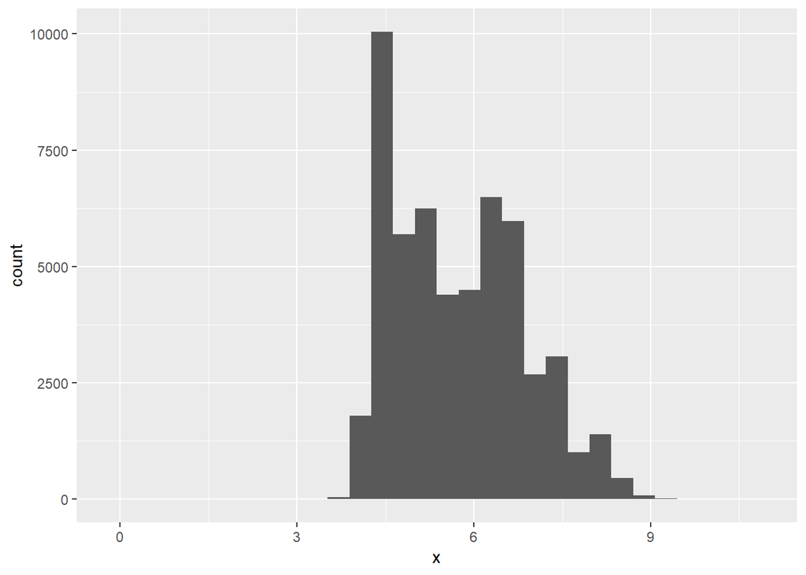

```r
ggplot(data=diamonds) + geom_histogram(mapping=aes(x=x))
```

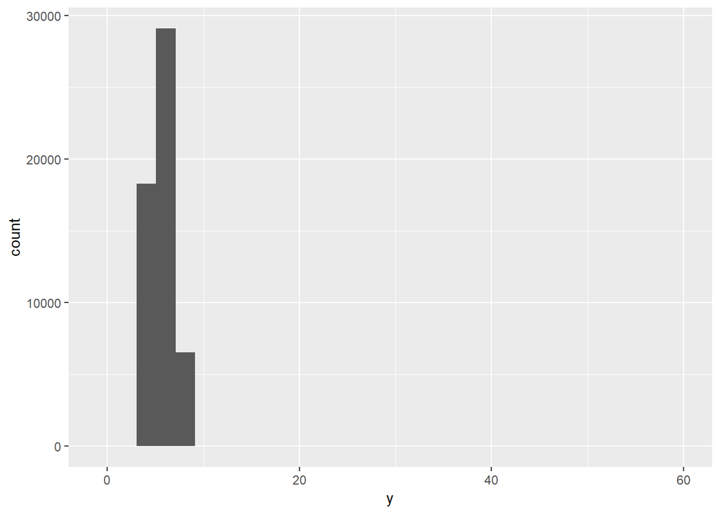

```r
ggplot(data=diamonds) + geom_histogram(mapping=aes(x=y))
```

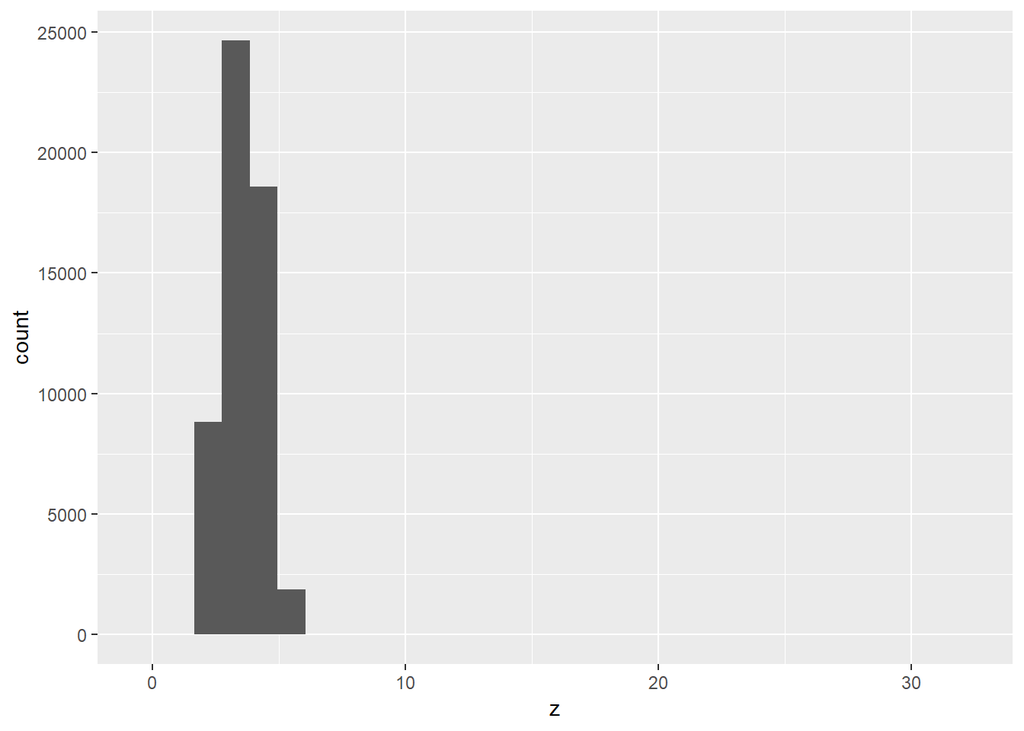

```r
ggplot(data=diamonds) + geom_histogram(mapping=aes(x=z))
```

### 2. Explore the distribution of price. Do you discover anything unusual or surprising? (Hint: Carefully think about the binwidth and make sure you try a wide range of values.)

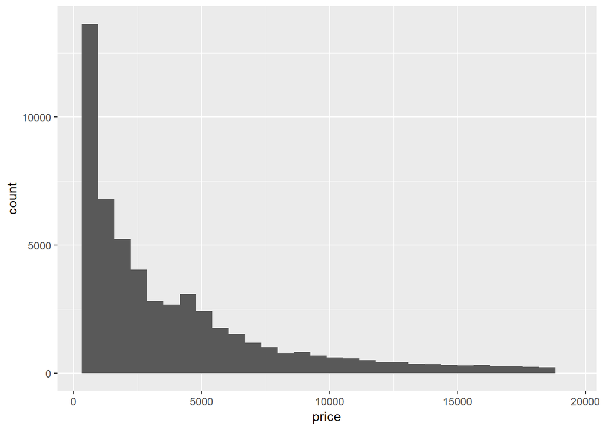

```r
ggplot(data=diamonds) + geom_histogram(mapping = aes(x=price))
```

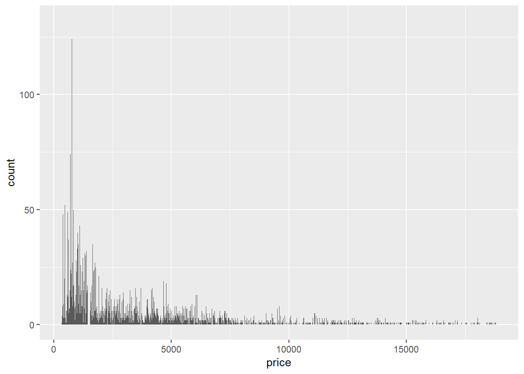

```r
ggplot(data=diamonds) + geom_histogram(mapping = aes(x=price),binwidth = 1)
```

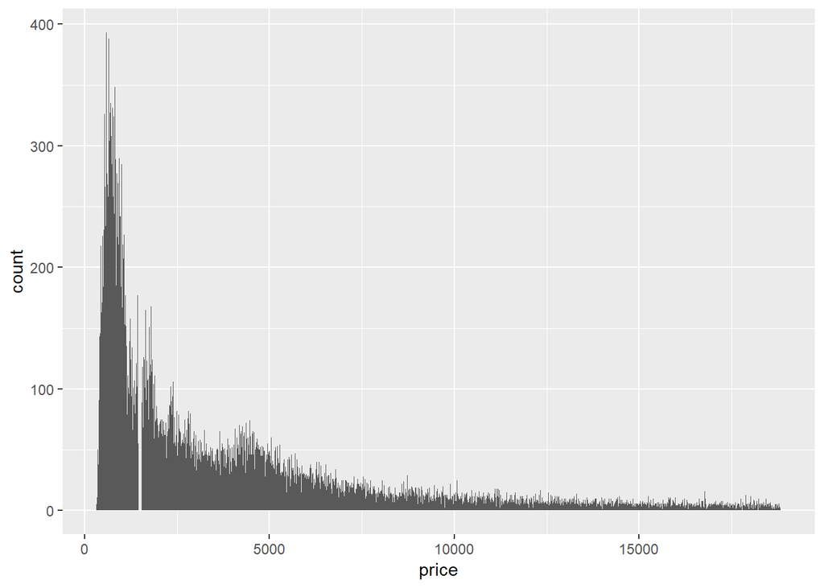

```r
ggplot(data=diamonds) + geom_histogram(mapping=aes(x=price),binwidth = 10)
```

I find it unusual at how many diamonds were at such a low price point. I also find it interesting that when you decrease the bin size, you can see that certain price points have a peak in count compared to those around them. I wonder what the reasoning for that is.

### 3. How many diamonds are 0.99 carat? How many are 1 carat? What do you think is the cause of the difference?

```r
(bid_diamonds <- diamonds %>% filter(carat == .99))
```

```
## # A tibble: 23 x 10
##    carat cut       color clarity depth table price     x     y     z
##    <dbl> <ord>     <ord> <ord>   <dbl> <dbl> <int> <dbl> <dbl> <dbl>
##  1  0.99 Fair      I     SI2      68.1    56  2811  6.21  6.06  4.18
##  2  0.99 Fair      J     SI1      55      61  2812  6.72  6.67  3.68
##  3  0.99 Fair      J     SI1      58      67  2949  6.57  6.5   3.79
##  4  0.99 Fair      I     SI1      60.7    66  3337  6.42  6.34  3.87
##  5  0.99 Fair      H     VS2      71.6    57  3593  5.94  5.8   4.2
##  6  0.99 Very Good J     SI1      60.3    57  4002  6.44  6.49  3.9
##  7  0.99 Good      F     SI2      63.3    54  4052  6.36  6.43  4.05
##  8  0.99 Premium   F     SI2      60.6    61  4075  6.45  6.38  3.89
##  9  0.99 Ideal     I     SI1      61.8    57  4763  6.4   6.42  3.96
## 10  0.99 Very Good E     SI2      61.8    59  4780  6.3   6.33  3.9
## # ... with 13 more rows
```

```r
(bid_diamonds <- diamonds %>% filter(carat == 1))
```

```
## # A tibble: 1,558 x 10
##    carat cut     color clarity depth table price     x     y     z
##    <dbl> <ord>   <ord> <ord>   <dbl> <dbl> <int> <dbl> <dbl> <dbl>
##  1     1 Premium I     SI2      58.2    60  2795  6.61  6.55  3.83
##  2     1 Premium J     SI2      62.3    58  2801  6.45  6.34  3.98
##  3     1 Fair    G     I1       66.4    59  2808  6.16  6.09  4.07
##  4     1 Fair    J     VS2      65.7    59  2811  6.14  6.07  4.01
##  5     1 Premium H     I1       61.3    60  2818  6.43  6.39  3.93
##  6     1 Fair    H     SI2      65.3    62  2818  6.34  6.12  4.08
##  7     1 Premium F     I1       58.9    60  2841  6.6   6.55  3.87
##  8     1 Fair    G     SI2      67.8    61  2856  5.96  5.9   4.02
##  9     1 Fair    I     SI1      67.9    62  2856  6.19  6.03  4.15
## 10     1 Fair    H     SI2      66.1    56  2856  6.21  5.97  4.04
## # ... with 1,548 more rows
```

There are 23 diamonds with .99 carats and there are 1558 diamonds with 1 carat. This is mostly caused by either a lack of instument precision, human error, or people purposefully rounding up for business reasons.

### 4. Compare and contrast coord_cartesian() vs xlim() or ylim() when zooming in on a histogram. What happens if you leave binwidth unset? What happens if you try and zoom so only half a bar shows?

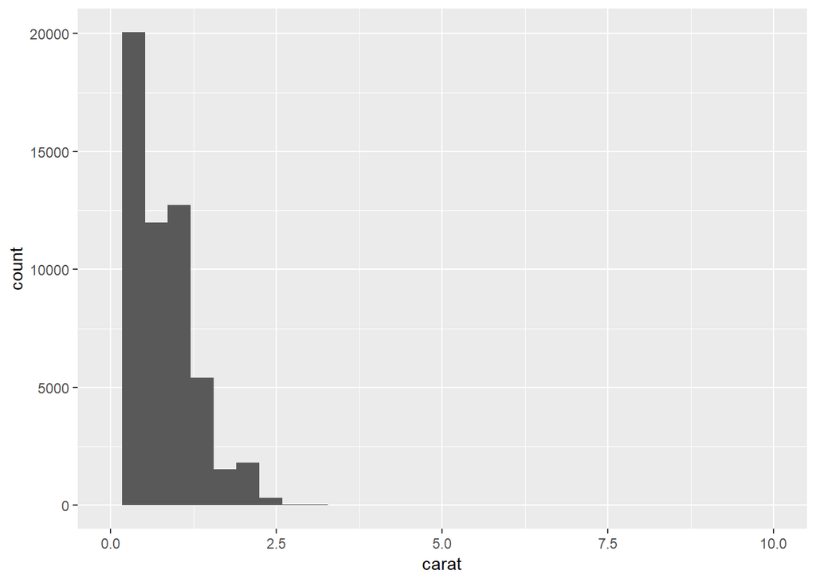

```r
ggplot(data=diamonds) + geom_histogram(mapping = aes(x=carat))
ggplot(data=diamonds) + geom_histogram(mapping = aes(x=carat)) + coord_cartesian()
ggplot(data=diamonds) + geom_histogram(mapping = aes(x=carat)) + xlim(0,10)
```

[output not shown]

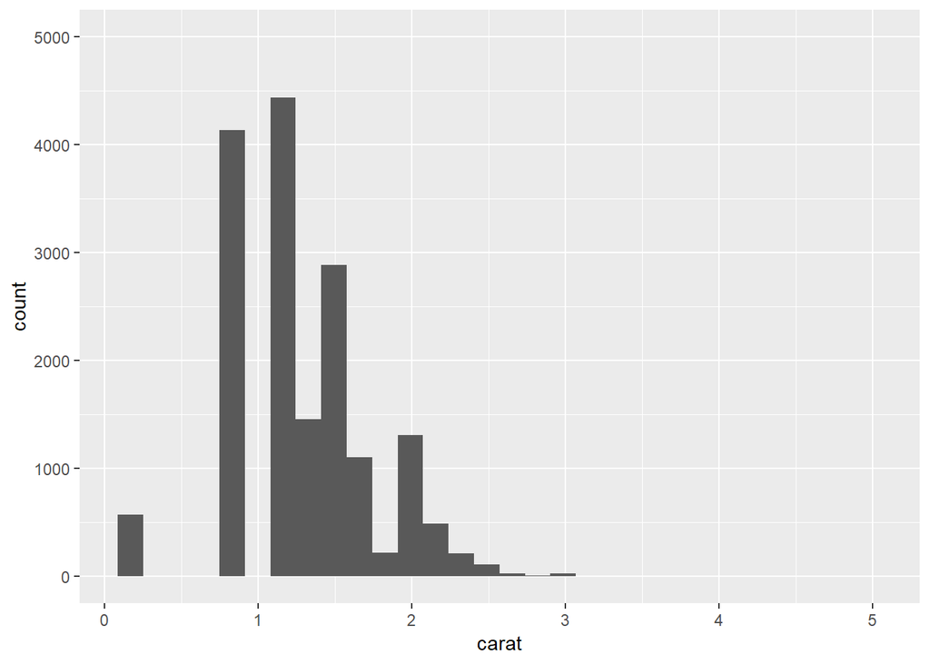

```r
ggplot(data=diamonds) + geom_histogram(mapping = aes(x=carat)) + ylim(0,5000)
```

If you leave the bindwidth unset, it will default to taking the range of values and dividing it by the default number of bins, which is 30. By itself. coord_cartesian does nothing unless you specify a specific x or y limit in it. xlim and ylim on the other hand require you to specify the lower and upper limits of your plot and will cutoff ay values that extend past that limit. If the y value extends past it, it will delete the entire column. For example if you cut the ylim to half of the max count, any column that exceeds that count will be left empty.

## 7.4.1 Exercises

### 1. What happens to missing values in a histogram? What happens to missing values in a bar chart? Why is there a difference?

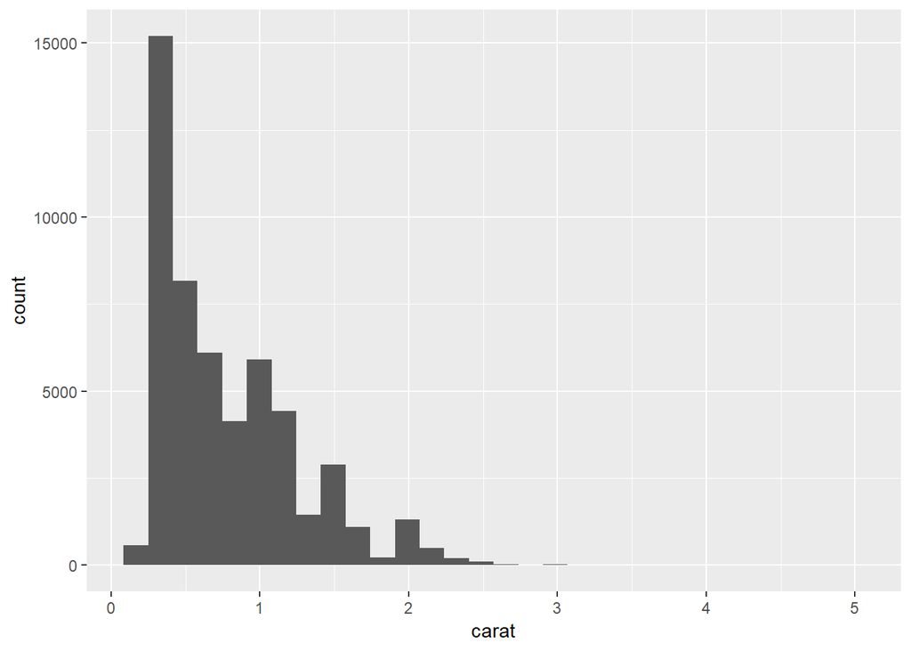

```r
ggplot(data=diamonds) + geom_histogram(mapping = aes(x=carat))
cheap <- diamonds %>% mutate(carat = ifelse(carat == 1 , NA, carat))
ggplot(data=cheap) + geom_histogram(mapping = aes(x=carat))
```

[output not shown]

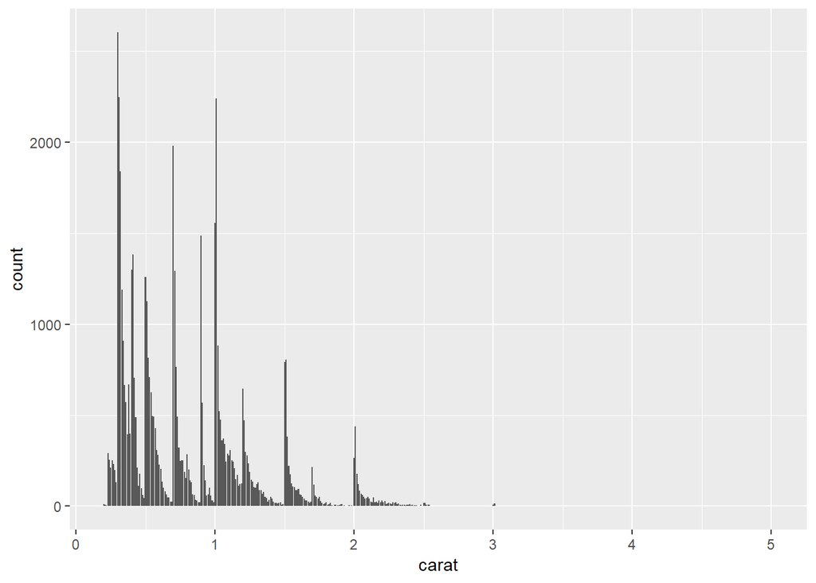

```r
ggplot(data=diamonds) + geom_bar(mapping = aes(x=carat))
```

[figure not shown]

```r
ggplot(data=cheap) + geom_bar(mapping=aes(x=carat))
```

### 2. What does na.rm = TRUE do in mean() and sum()?

```r
flights %>%
  group_by(year, month, day) %>%
  summarise(mean = mean(dep_delay),sum = sum(dep_delay))
```

```
## # A tibble: 365 x 5
## # Groups:   year, month [?]
##     year month   day  mean   sum
##    <int> <int> <int> <dbl> <dbl>
##  1  2013     1     1    NA    NA
##  2  2013     1     2    NA    NA
##  3  2013     1     3    NA    NA
##  4  2013     1     4    NA    NA
##  5  2013     1     5    NA    NA
##  6  2013     1     6    NA    NA
##  7  2013     1     7    NA    NA
##  8  2013     1     8    NA    NA
##  9  2013     1     9    NA    NA
## 10  2013     1    10    NA    NA
## # ... with 355 more rows
```

```r
flights %>%
  group_by(year, month, day) %>%
  summarise(mean = mean(dep_delay, na.rm = TRUE),sum = sum(dep_delay, na.rm = TRUE))
```

```
## # A tibble: 365 x 5
## # Groups:   year, month [?]
##     year month   day  mean   sum
##    <int> <int> <int> <dbl> <dbl>
##  1  2013     1     1 11.5   9678
##  2  2013     1     2 13.9  12958
##  3  2013     1     3 11.0   9933
##  4  2013     1     4  8.95  8137
##  5  2013     1     5  5.73  4110
##  6  2013     1     6  7.15  5940
##  7  2013     1     7  5.42  5038
##  8  2013     1     8  2.55  2285
##  9  2013     1     9  2.28  2042
## 10  2013     1    10  2.84  2643
## # ... with 355 more rows
```

The na.rm = TRUE searches through the dep_delays in this case and removes any case where there is NA instead of an actual result. This is important to include in both sum and mean because otherwise you get NA as your output because R cannot assume what the sum of a number and NA would be.

##.7.5.1.1 Exercises

### 1. Use what you’ve learned to improve the visualisation of the departure times of cancelled vs. non-cancelled flights.

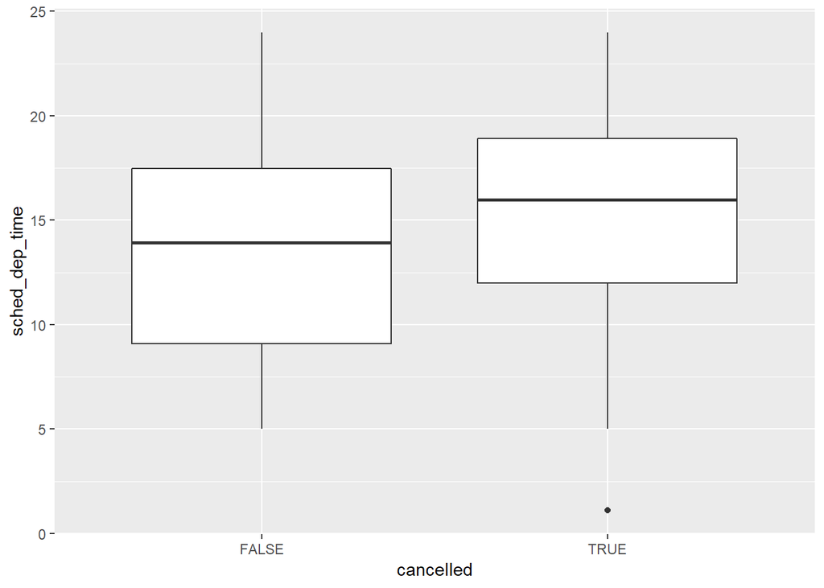

```r
fl <-
  flights %>%
  mutate(cancelled = is.na(dep_time),sched_hour = sched_dep_time %/% 100,sched_min = sched_dep_time %% 100,sched_dep_time = sched_hour + sched_min / 60)

fl %>%
  ggplot(aes(cancelled, sched_dep_time)) +
  geom_boxplot()
```

### 2. What variable in the diamonds dataset is most important for predicting the price of a diamond? How is that variable correlated with cut? Why does the combination of those two relationships lead to lower quality diamonds being more expensive?

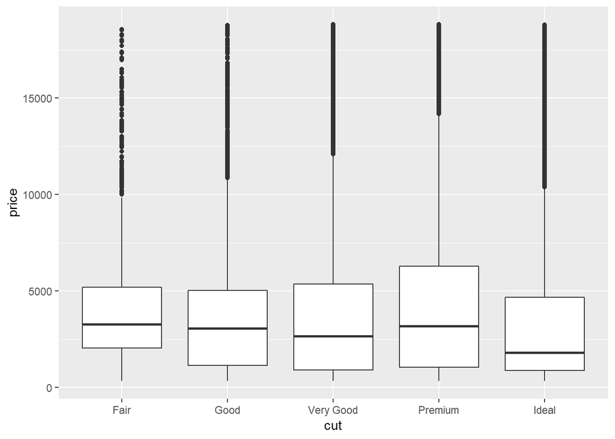

```r
diamonds %>%
  ggplot(aes(cut, price)) +
  geom_boxplot()
```

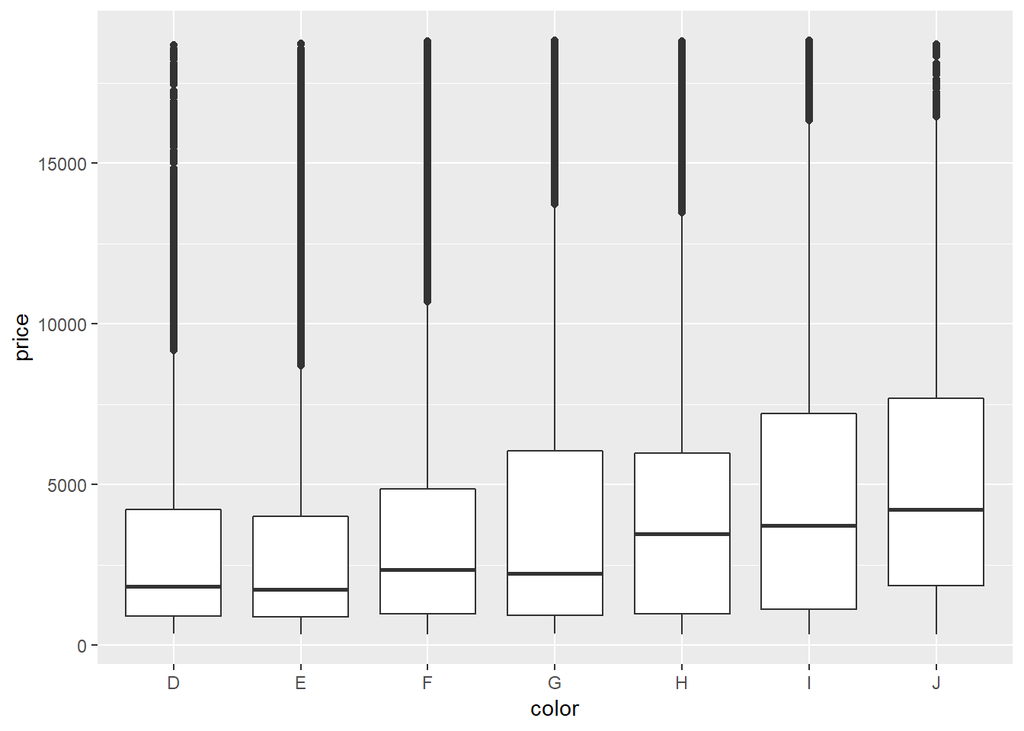

```r
diamonds %>%
  ggplot(aes(color, price)) +
  geom_boxplot()
```

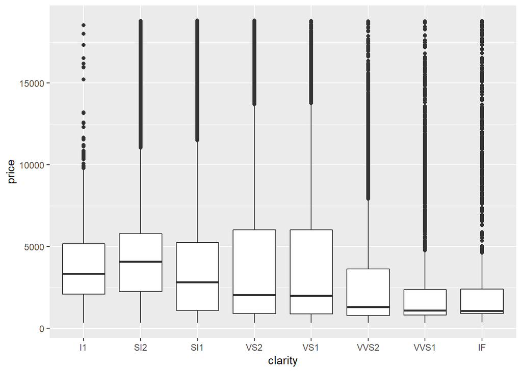

```r
diamonds %>%
  ggplot(aes(clarity, price)) +
  geom_boxplot()
```

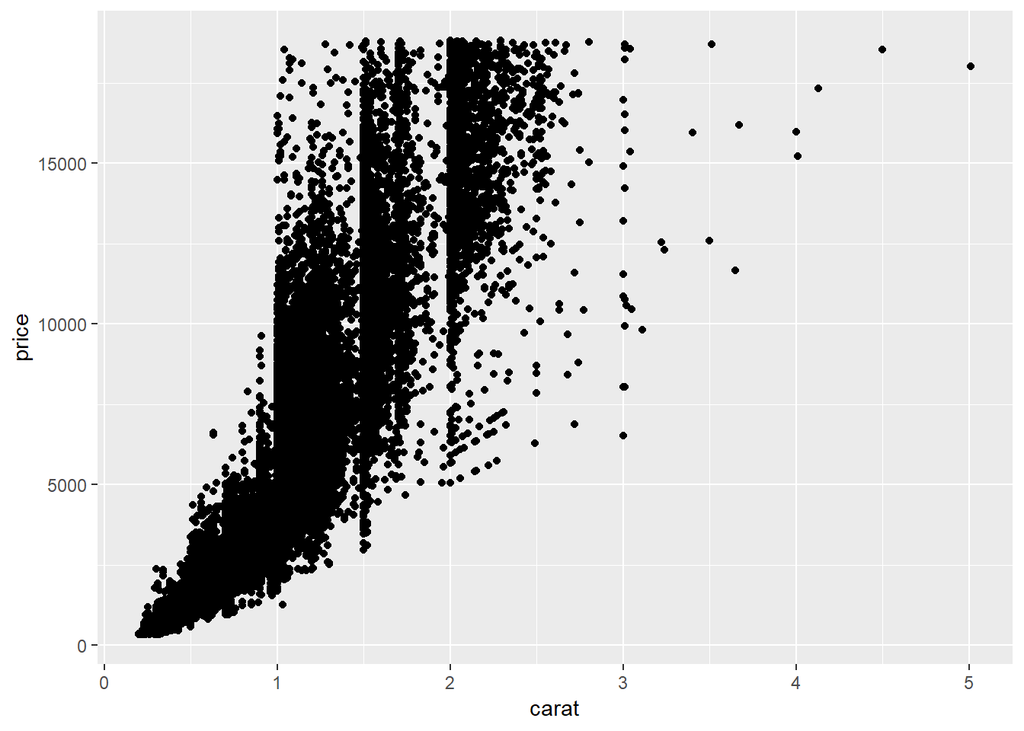

```r
diamonds %>%
  ggplot(aes(carat,price)) + geom_point()
```

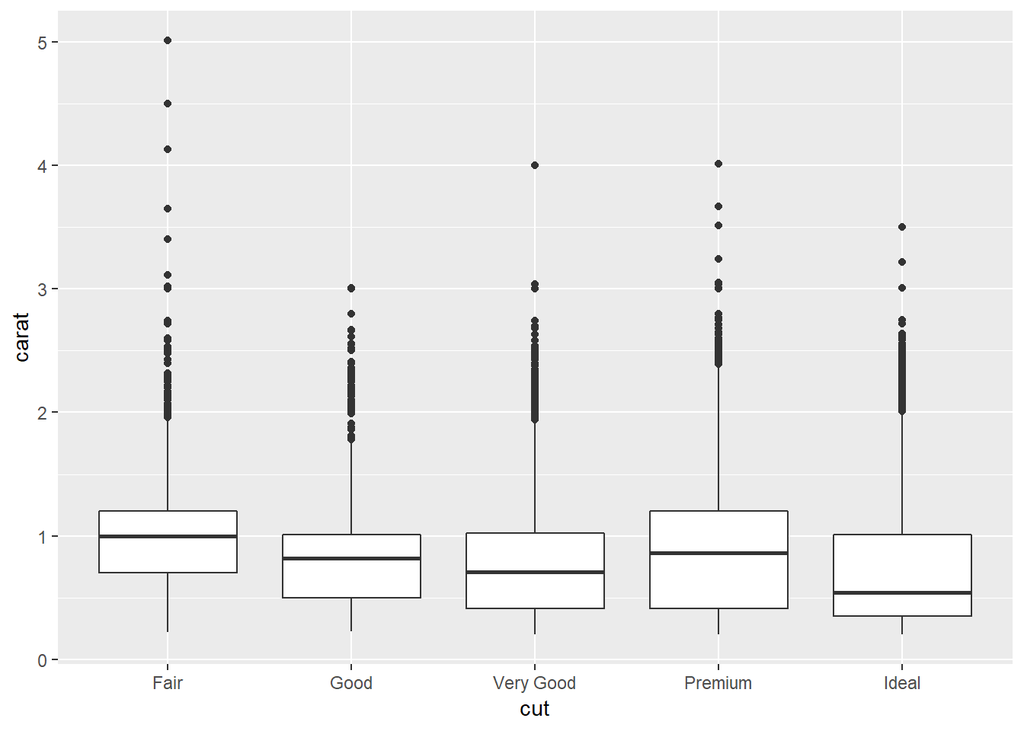

```r
diamonds %>%
  ggplot(aes(cut,carat)) + geom_boxplot()
```

### 3. Install the ggstance package, and create a horizontal boxplot. How does this compare to using coord_flip()?

```r
#install.packages("ggstance")
library(ggstance)
```

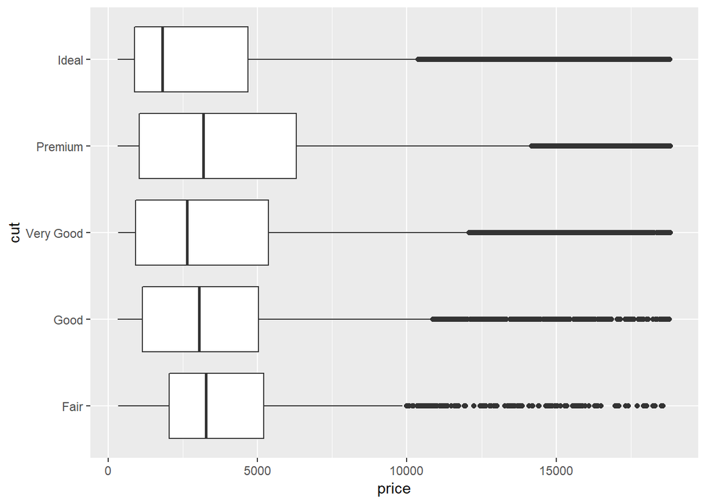

```r
diamonds %>%
  ggplot(aes(cut, price)) +
  geom_boxplot() +
  coord_flip()
```

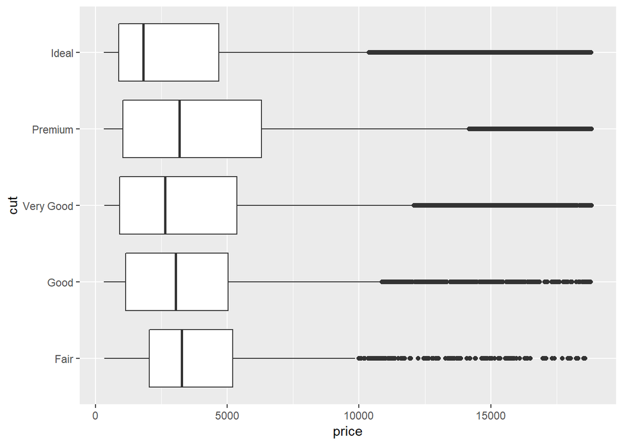

```r
diamonds %>%
  ggplot(aes(price, cut)) +
  geom_boxploth()
```

The boxplots look the exact same but using the geom_boxploth() from ggstance requires less keystrokes. In addition, I had to reverse the order of variables because it does not flip them the way that coord_flip does.

### 4. One problem with boxplots is that they were developed in an era of much smaller datasets and tend to display a prohibitively large number of “outlying values”. One approach to remedy this problem is the letter value plot. Install the lvplot package, and try using geom_lv() to display the distribution of price vs cut. What do you learn? How do you interpret the plots?

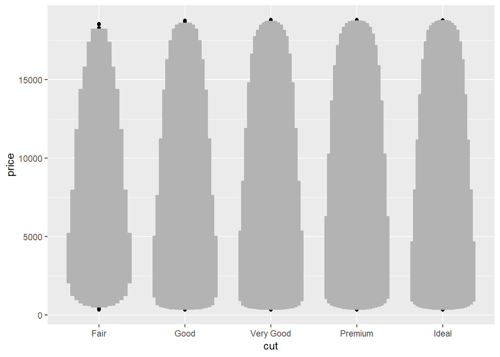

```r
#install.packages("lvplot")
library(lvplot)

diamonds %>%
  ggplot(aes(cut,price))+
  geom_lv()
```

The difference in this type of plot is that the varying widths allow you to know what proportion of the data is at that specific price point for that cut. This type of plot is much better for viewing information about the tails of a dataset, while boxplots allow you to quickly get information about the central 50%. This type of plot also finds much less outliers because the formula used for calculating it is not just based on the IQR.

### 5. Compare and contrast geom_violin() with a facetted geom_histogram(), or a coloured geom_freqpoly(). What are the pros and cons of each method?

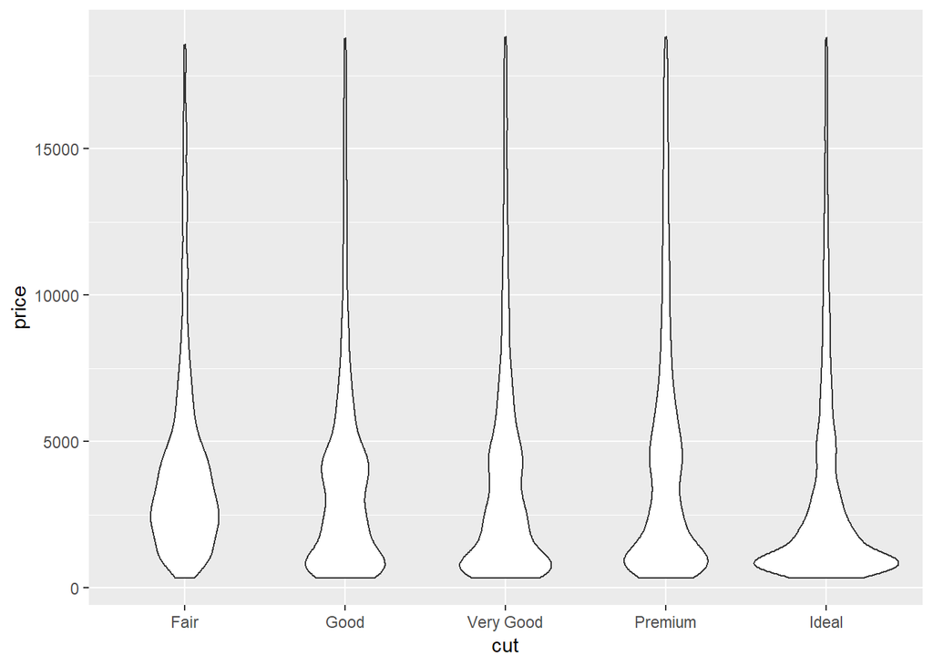

```r
diamonds %>%
  ggplot(aes(cut,price)) +
  geom_violin()
```

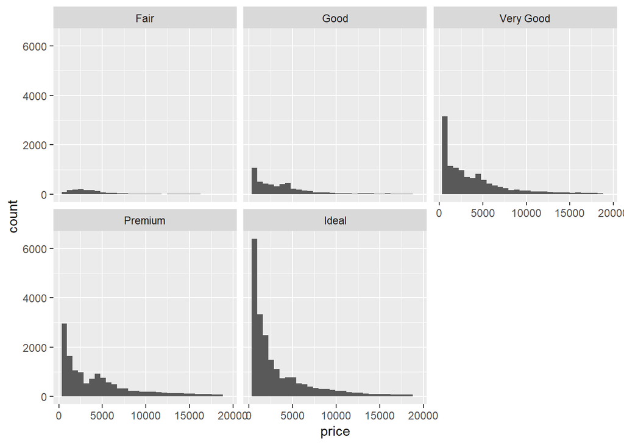

```r
diamonds %>%
  ggplot(aes(price)) +
  geom_histogram() +
  facet_wrap(~cut)
```

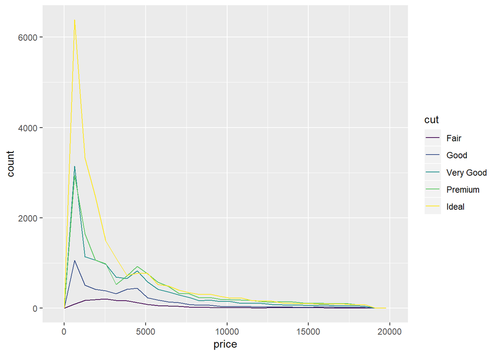

```r
diamonds %>%
  ggplot(aes(price)) +
  geom_freqpoly(aes(colour = cut))
```

The violin plot is good because the width of the plots correlates to the proportion of the total data that is in that price range, which makes it easy to see how the price varies amongst a given cut quality. This plot however only really seems helpful for the areas that have a good proportion of the dataset, because once you get past $10000 all the lines look essentially the same thickness until the end. This plot is also generally good at letting you see where the majority of the data for the different cut qualities lie against each other at a quick glance.

I believe the histogram is the best for analyzing how the price varies amongst a given cut size, but is not as good for comparing the different cut qualities at the same time as the freq_poly plot. Another positive for this plot is that it is the easiest to read numerically and get a good grasp at what the values truely are. You could also add more variables to the histogram and break the columns up by color or something else.

The freqpoly plot with color is a great way to quickly visualize how the count differs for the different diamond cuts at a specific price point. The plot is not good when all the groups have similiar counts for the same price, such as in the 15000-20000 range on this plot. It becomes almost impossible to distinguish which has a higher count for those values.

### 6. If you have a small dataset, it’s sometimes useful to use geom_jitter() to see the relationship between a continuous and categorical variable. The ggbeeswarm package provides a number of methods similar to geom_jitter(). List them and briefly describe what each one does.

```r
#install.packages("ggbeeswarm")
#library(ggbeeswarm)
#?ggbeeswarm
```

geom_beeswarm offsets points within categories to reduce overplotting geom_quasirandom uses vipor package to add jitter and reduce oveplotting position_beeswarm makes violin point plots to show overlapping points position_quasirandom does the same thing

## 7.5.2.1 Exercises

### 1.How could you rescale the count dataset above to more clearly show the distribution of cut within colour, or colour within cut?

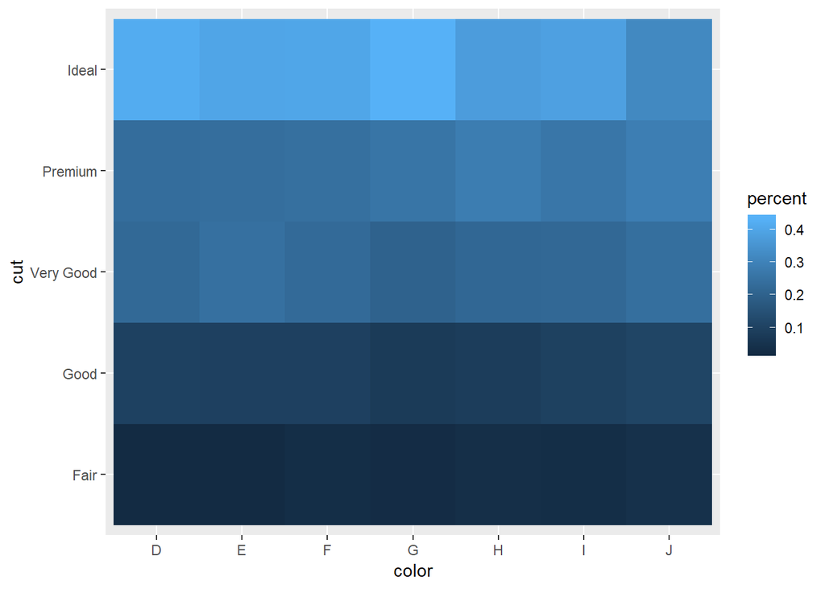

```r
diamonds %>%
  count(color, cut) %>%
  group_by(color) %>%
  mutate(percent = n / sum(n)) %>%
  ggplot(aes(color, cut, fill = percent)) +
  geom_tile()
```

### 2. Use geom_tile() together with dplyr to explore how average flight delays vary by destination and month of year. What makes the plot difficult to read? How could you improve it?

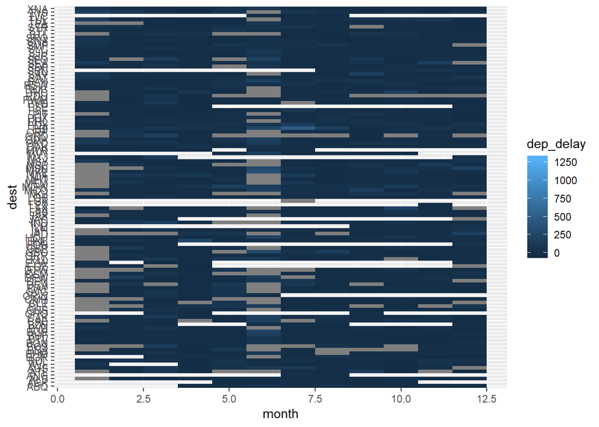

```r
flights %>%
  ggplot(aes(x = month, y = dest, fill = dep_delay)) +
  geom_tile()
```

The plot is very hard to read because there are so many different destinations that the axis becomes hard to read and impossible to tell what lines up where. A better way you could do this would be to rank the top 10 best and worst destinations by flight delay.

### 3. Why is it slightly better to use aes(x = color, y = cut) rather than aes(x = cut, y = color) in the example above?

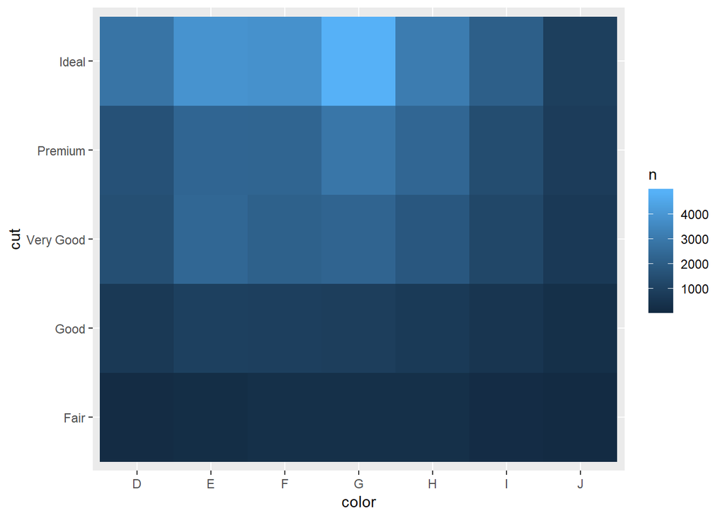

```r
diamonds %>%
  count(color, cut) %>%
  ggplot(mapping = aes(x = color, y = cut)) +
    geom_tile(mapping = aes(fill = n))
```

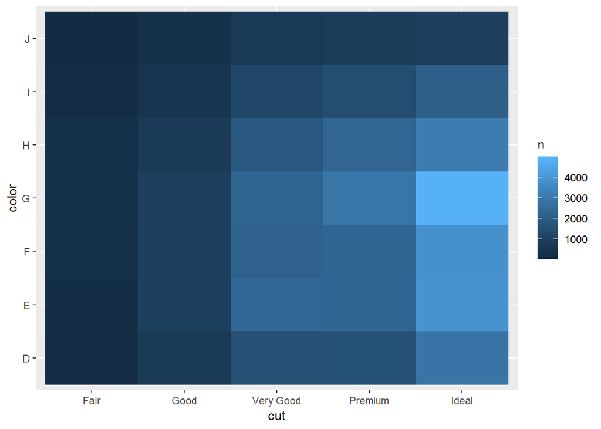

```r
diamonds %>%
  count(color, cut) %>%
  ggplot(mapping = aes(x = cut, y = color)) +
    geom_tile(mapping = aes(fill = n))
```

Cut is an ordered categorical variable, while color is not. We are normally used to using plots like bar charts and such where the y axis is ordered, although in this case it is not continuous.

## 7.5.3.1 Exercises

### 1. Instead of summarising the conditional distribution with a boxplot, you could use a frequency polygon. What do you need to consider when using cut_width() vs cut_number()? How does that impact a visualisation of the 2d distribution of carat and price?

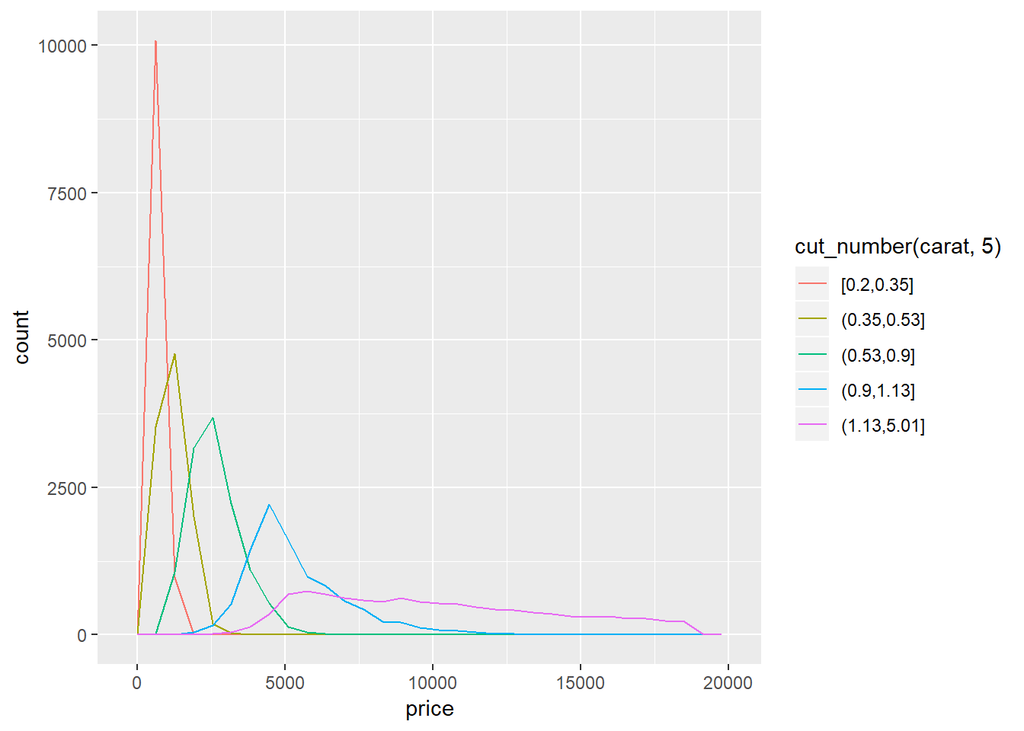

```r
ggplot(data = diamonds, mapping = aes(color = cut_number(carat, 5), x = price)) +
  geom_freqpoly()
```

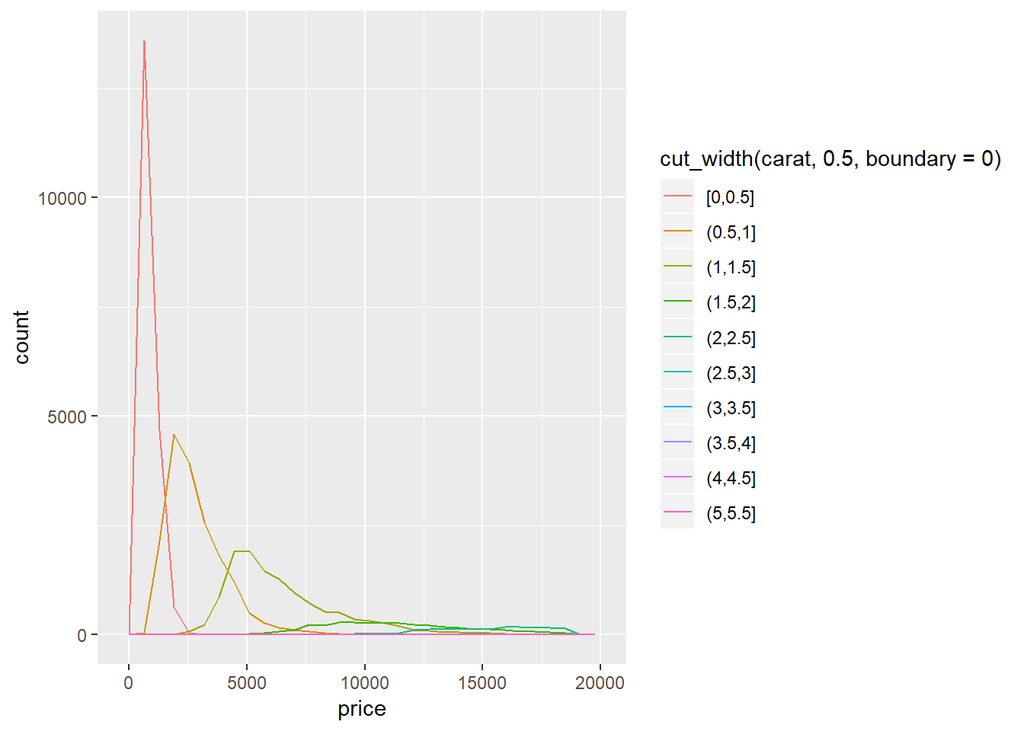

```r
ggplot(data = diamonds,mapping = aes(color = cut_width(carat, 0.5, boundary = 0), x = price)) +
  geom_freqpoly()
```

For cut_width, you need to specify the width we are choosing, but for cut_number you only need to specify how many groups you want. When doingit by cut_number, it will separate the amount of reads into 5 groups of the same size, while using cut_width it breaks it down by those specific width measurements, not matter what the count of those groups is. Knowing how these two are treated differently helps you understand the differences in the plot visualizations and why the area of the groups changes.

### 2. Visualise the distribution of carat, partitioned by price.

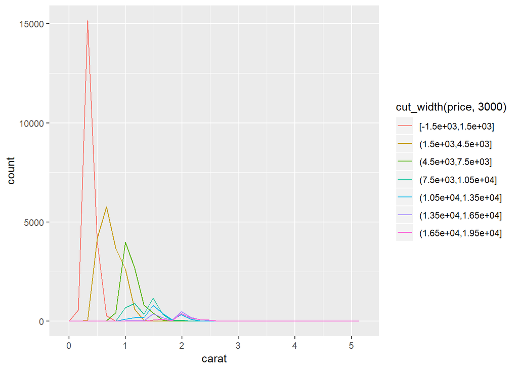

```r
ggplot(diamonds, aes(carat, colour = cut_width(price, 3000))) +
  geom_freqpoly()
```

### 3. How does the price distribution of very large diamonds compare to small diamonds. Is it as you expect, or does it surprise you?

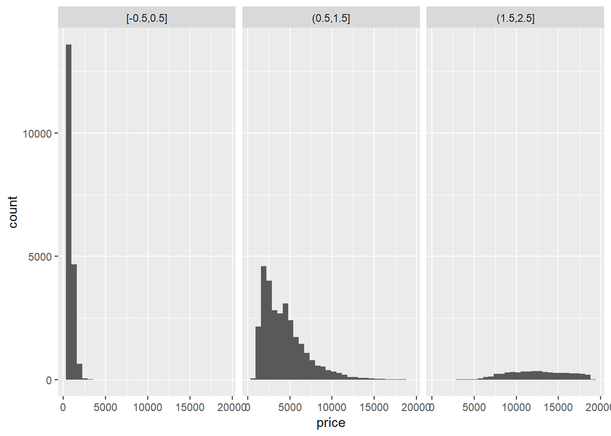

```r
diamonds %>%
  filter(between(carat, 0, 2.5)) %>%
  mutate(carat = cut_width(carat, 1)) %>%
  ggplot(aes(price)) + geom_histogram() + facet_wrap(~ carat)
```

### 4. Combine two of the techniques you’ve learned to visualise the combined distribution of cut, carat, and price.

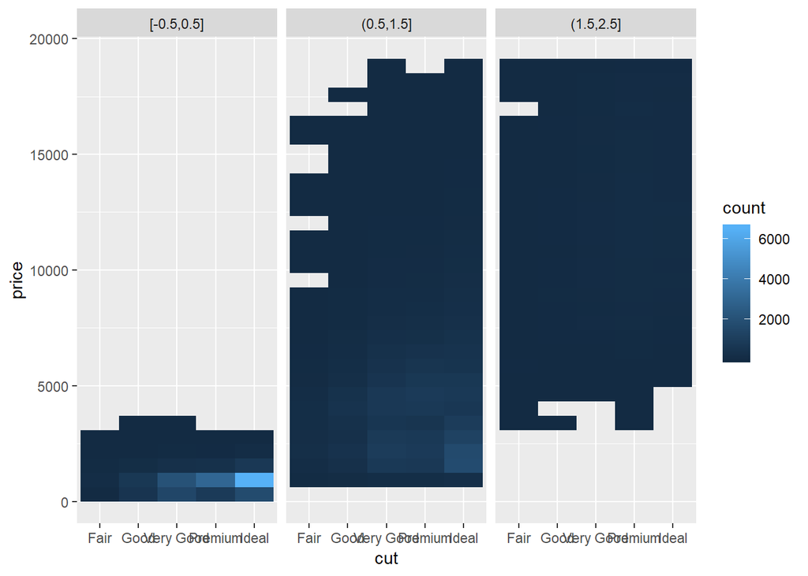

```r
diamonds %>%
  filter(between(carat, 0, 2.5)) %>%
  mutate(carat = cut_width(carat, 1)) %>%
  ggplot +
  geom_bin2d(mapping = aes(x = cut, y = price)) + facet_wrap(~ carat)
```